# Predicting intraday high-frequency stock prices

## Background and Motivation

The stock market is one of the most challenging environments to predict due to its dynamic nature and significant noise, as players often create "false moves" to deceive others. However, a few individuals manage to profit from intraday movements. Successful traders distinguish themselves by taking high probability-risk trades, where the average profit per trade is a multiple of the average loss, even if they only predict the stock direction correctly 50% of the time.

Human traders face two main challenges:

1. Emotional detachment and systematic trading.
2. The ability to trade only one asset at a time.

A fully automated trading algorithm addresses the first challenge by removing emotions from trading decisions. Day traders typically use scanners configured with predefined criteria (e.g., a stock's trading volume being 1.5 times its average). The trader then examines each stock that appears on the scanner, assesses its chart and characteristics (sector, standard deviations, average volume, etc.), and exercises judgment to identify potential profit opportunities. If a promising entry point is identified after a pattern emerges, the trader executes a buy/sell order, often using a stop-loss and take-profit orders to manage risk. The stop loss can be set at a level where the trader believes the trade is no longer valid, and the take profit can be set at a level where the trader believes the stock will reach.

Let's do an example. Soundhound $SOUN is a highly speculative stock that has risen 20% in the day prior to today. This has attracted a lot of day traders to this stock today because of the aggressive move. It is currently 11:35 in the trading session and after peaking at 5.30 in the early trading, the stock is now down to 4.89.

[figure not shown]

The trader recognizes that this level has been touched multiple times today and looks like a good support level. Now the trader assesses the risk-reward ratio. What is a likely price the stock will go to if it bounces from the current level? 5 sounds like a good price because its a round number and it has acted as a key level in the past few days. The trader also assesses the risk. Where would he place the stop-loss in case the price doesn't bounce off the support? Looking at the session lows, the stock has not dipped below 4.85, which means that the trader can place a stop-loss at 4.84. This means that the trader is risking 5 cents to make 11 cents. This is a 2:1 risk-reward ratio. The trader decides to take the trade because the risk-reward ratio is greater than 2:1. Next thing you know, the stock bounces off the support and reaches 5.00. The trader takes profit and makes 11 cents per share.

[figure not shown]

This is an example of how leveraging risk-reward rations can help traders be profitable in the stock market. Predicting a stock's price direction is very hard and would be almost impossible to do with over 50% accuracy, but taking trades where a take-profit is greater than the stop-loss can help traders be profitable even if they are right only 50% of the time.

### Project Goal

**Making Money** Identifying high reward to risk ratio trades is key to succeeding as a trader. A theoretical model that can predict stock prices with accuracy of 100% would allow traders to make a profit in a every single trade with 0 risk. Such model is impossible to build due to the random nature of the stock market. However, an explainable model that has high precision in identifying move directions can be extremely valuable as a reward-risk ratio tool. This project aims to build a model that predicts stock prices in a short range of time with **high precision** (not recall or accuracy), and backtest a trading strategy that uses this model. The reason I choose the maximize precision is because I aim to find the trades with the highest probability instead of finding many trades that have only a small edge.

#### Candlestick Charts

Candlestick charts are a type of financial chart used to describe price movements of a security, derivative, or currency. Each candlestick typically represents one day's worth of price data about a stock through four pieces of information: the opening price, the closing price, the high price, and the low price. The color of the candlestick represents the direction of the price movement, with green indicating that the closing price was higher than the opening price, and red indicating that the closing price was lower than the opening price.

## importing libraries and setting global settings

```python
import concurrent.futures
import json
from datetime import datetime
from pathlib import Path

import numpy as np
from sklearn.preprocessing import StandardScaler
from tensorboard.backend.event_processing.event_accumulator import EventAccumulator
%load_ext autoreload
%autoreload 2
%matplotlib inline
import pandas as pd
from backtest import backtest_ema_strategy, backtest_bnh_strategy, describe_strategy_result, backtest_rsi_strategy
import yfinance as yf
from utils import get_daily_df, historic_resistances, historic_supports
import json
import pandas_ta as ta
import warnings
import seaborn as sns
import matplotlib.pyplot as plt
from plots import plot_bars_with_indicators
import mplfinance as mpf
from tqdm.notebook import tqdm
import pytorch_optimizer
import lightning.pytorch as pl
from lightning.pytorch.callbacks import EarlyStopping, LearningRateMonitor
from lightning.pytorch.loggers import TensorBoardLogger
from pytorch_forecasting import Baseline, TemporalFusionTransformer, TimeSeriesDataSet
from pytorch_forecasting.data import GroupNormalizer
from pytorch_forecasting.metrics import MAE, SMAPE, PoissonLoss, QuantileLoss
from pytorch_forecasting.models.temporal_fusion_transformer.tuning import optimize_hyperparameters
from backtest import backtest_tft_strategy

tqdm.pandas()

warnings.filterwarnings("ignore")
```

```python
# Set global settings
IS_CLEAN_RUN = False
RUN_BACKTESTS = True
DATA_CUTOFF = datetime(2024, 7, 11)
DATA_START = datetime(2024, 1, 1)
```

## Data Loading And Cleaning

```python
if IS_CLEAN_RUN:
    # Step 1: Get all JSONL files in the data directory
    data_path = Path("/Users/iverkh/trading_bots/data/intra_day")
    jsonl_files = [file for symbol in data_path.iterdir() if symbol.is_dir() for file in symbol.iterdir() if file.suffix == ".jsonl"]

    # Step 2: Function to read a single JSONL file
    def read_jsonl(file):
        return pd.read_json(file, orient="records", lines=True)

    # Step 3: Read files in parallel and concatenate in batches
    batch_size = 100  # Adjust the batch size according to your memory capacity
    dataframes = []

    with concurrent.futures.ThreadPoolExecutor() as executor:
        for i in tqdm(range(0, len(jsonl_files), batch_size), desc="Reading JSONL files..."):
            batch_files = jsonl_files[i:i+batch_size]
            batch_dfs = list(executor.map(read_jsonl, batch_files))
            dataframes.append(pd.concat(batch_dfs, axis=0))

    # Step 4: Concatenate all batches
    df = pd.concat(dataframes, axis=0)
    df.to_parquet("data.parquet")
else:
    df = pd.read_parquet("data.parquet")
    df.set_index("datetime", inplace=True)
```

```python
df["date"] = df.index.date
df["hour"] = df.index.hour
df["minute"] = df.index.minute
df.sort_index(inplace=True)
df.sort_values(["symbol", "datetime"], inplace=True)
```

```python
df.info()
print(f"Number of total rows: {df.shape[0]}")
```

```
<class 'pandas.core.frame.DataFrame'>
DatetimeIndex: 66483995 entries, 2024-01-04 09:31:00 to 2024-07-17 16:00:00
Data columns (total 9 columns):
 #   Column  Dtype
---  ------  -----
 0   open    float64
 1   high    float64
 2   low     float64
 3   close   float64
 4   volume  int64
 5   date    object
 6   symbol  object
 7   hour    int32
 8   minute  int32
dtypes: float64(4), int32(2), int64(1), object(2)
memory usage: 4.5+ GB
Number of total rows: 66483995
```

### Filtering Low Liquidity Stocks

The dataset consists of over 66 million rows of OHLCV bars, which is beyond the manageable scope for this project. To reduce the data size, I will calculate what I refer to as the “stock average nominal volume” for each stock. This metric is defined as the median trading volume of the stock multiplied by its average price, providing a normalized representation of the average daily dollar amount traded for that stock. By applying this calculation to the resampled daily bars dataframe, I can effectively assess the liquidity of each stock. Subsequently, I will filter the dataframe to retain only the top 100 most traded stocks in terms of nominal value (usually big and established companies), and 100 stocks with high median volume (could be highly speculative stocks).

$$ \text{Stock Average Nominal Volume}_i = \text{Median Volume}_i \times \text{Average Price}_i $$

Where:

Median Volume (i) is the median daily trading volume for stock i. Average Price (i) is the average daily closing price for stock i.

```python
def resample_to_daily(group):
    resampled_group = group.resample('D').agg({
        'open': 'first',
        'high': 'max',
        'low': 'min',
        'close': 'last',
        'volume': 'sum'
    }).dropna()
    return resampled_group

# Apply the resampling function to each group
df_daily = df.groupby('symbol').apply(resample_to_daily).reset_index()
df_daily["stock_median_volume"] = df_daily.groupby("symbol")["volume"].transform("median").astype(int)
df_daily["stock_average_price"] = df_daily.groupby("symbol")["close"].transform("mean")
df_daily["stock_average_nominal_volume"] = df_daily["stock_median_volume"] * df_daily["stock_average_price"]
top_100_symbols = df_daily.groupby("symbol")['stock_average_nominal_volume'].median().nlargest(100).index
top_100_volume = df_daily.groupby("symbol")['stock_median_volume'].median().nlargest(100).index
# Filter the DataFrame to keep only the top 100 stocks by nominal volume and top 100 stocks by median volume
df_daily = df_daily[df_daily['symbol'].isin(list(top_100_symbols) + list(top_100_volume))]
df = df[df['symbol'].isin(list(top_100_symbols) + list(top_100_volume))]
print(f"Number of total one minute bars after resampling: {df.shape[0]}")
print(f"Symbols: {df_daily.symbol.unique()}")
```

```
Number of total one minute bars after resampling: 8121299
Symbols: ['AAL' 'AAPL' 'ABBV' 'ABNB' 'ABT' 'ADBE' 'AGNC' 'ALTM' 'AMAT' 'AMC' 'AMD'
 'AMZN' 'ANET' 'AVGO' 'AXP' 'BA' 'BAC' 'BLUE' 'BMY' 'BTBT' 'C' 'CAT' 'CCL'
 'CDE' 'CHPT' 'CHWY' 'CIFR' 'CLF' 'CLSK' 'CMCSA' 'COIN' 'COP' 'COST'
 'CPNG' 'CRM' 'CRWD' 'CSCO' 'CSX' 'CVNA' 'CVS' 'CVX' 'DAL' 'DELL' 'DHR'
 'DIS' 'DKNG' 'DNA' 'ENPH' 'ET' 'F' 'FCEL' 'FCX' 'FFIE' 'FUBO' 'GE' 'GERN'
 'GEV' 'GM' 'GOOG' 'GOOGL' 'GS' 'HBAN' 'HD' 'HL' 'HOLO' 'HOOD' 'HPE' 'IBM'
 'INTC' 'JBLU' 'JNJ' 'JPM' 'KEY' 'KMI' 'KO' 'KVUE' 'LAZR' 'LCID' 'LLY'
 'LUMN' 'LYFT' 'MA' 'MARA' 'MCD' 'MDLZ' 'MDT' 'META' 'MO' 'MPW' 'MRK'
 'MRO' 'MRVL' 'MS' 'MSFT' 'MSTR' 'MU' 'NCLH' 'NEE' 'NEM' 'NFLX' 'NIO'
 'NKE' 'NOVA' 'NOW' 'NVDA' 'OPEN' 'ORCL' 'OXY' 'PACB' 'PANW' 'PARA' 'PATH'
 'PCG' 'PEP' 'PFE' 'PG' 'PLTR' 'PLUG' 'PM' 'PR' 'PTON' 'PYPL' 'QCOM'
 'RIOT' 'RIVN' 'RTX' 'RUN' 'SBUX' 'SCHW' 'SIRI' 'SMCI' 'SNAP' 'SNOW'
 'SOFI' 'SOUN' 'SQ' 'SWN' 'T' 'TGT' 'TJX' 'TLRY' 'TME' 'TMO' 'TMUS' 'TSLA'
 'TXN' 'U' 'UBER' 'UNH' 'V' 'VRT' 'WBA' 'WBD' 'WFC' 'WMT' 'WULF' 'XOM']
```

### Adding Fundamental Data

Traders often use fundamental data to assess a stock's "ID". Although it has less of an effect on intraday trading, it can still be useful to have this data to see the correlation between the stock's fundamentals and it's intraday price action.

```python
if IS_CLEAN_RUN:
    fundamental_data = {}
    maybe_delisted = []
    for stock in tqdm(df["symbol"].unique(), desc="Fetching fundamental data..."):
        ticker = yf.Ticker(stock)
        try:
            ticker_info = ticker.info
            fundamental_data[stock] = {
                "earning_dates": [date for date in ticker.earnings_dates.index if DATA_START.date() <= date.date() < DATA_CUTOFF.date()],
                "sector": ticker_info["sector"],
                "industry": ticker_info["industry"],
                "total_shares": ticker_info["sharesOutstanding"],
                "float_shares": ticker_info["floatShares"],
            }
        except Exception as e:
            maybe_delisted.append(stock)
            continue
    for stock in fundamental_data.keys():
        fundamental_data[stock]["earning_dates"] = [date.strftime("%Y-%m-%d %H:%M:%S") for date in fundamental_data[stock]["earning_dates"]]
    with open("fundamental_data.json", "w") as f:
        json.dump(fundamental_data, f)
else:
    with open("fundamental_data.json", "r") as f:
        fundamental_data = json.load(f)
df = df[df["symbol"].isin(list(fundamental_data.keys()))]
df = df[~(df["symbol"] == "GOOGL")] # Google has 2 classes of shares, their price is identical, so we will remove one
```

Example for fundamental data on Apple's stock:

```python
fundamental_data["AAPL"]
```

```
{'earning_dates': ['2024-05-02 16:00:00', '2024-02-01 16:00:00'],
 'sector': 'Technology',
 'industry': 'Consumer Electronics',
 'total_shares': 15204100096,
 'float_shares': 15179658339}
```

# Section 1: EDA and Feature Engineering

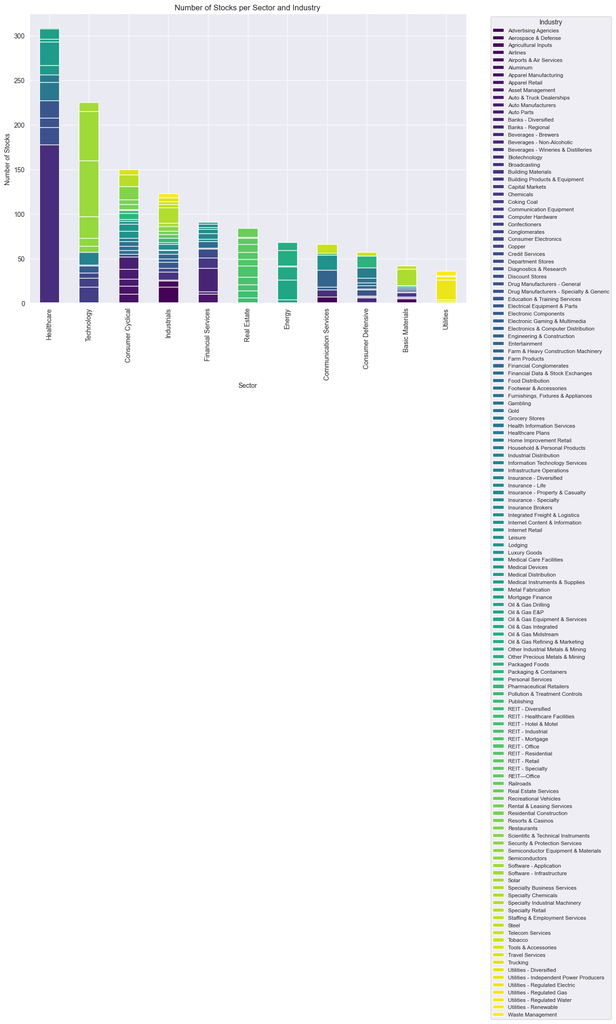

```python
fundamental_df = pd.DataFrame.from_dict(fundamental_data, orient='index')
sector_industry_counts = fundamental_df.groupby(['sector', 'industry']).size().unstack(fill_value=0)
sector_totals = sector_industry_counts.sum(axis=1)
sector_industry_counts = sector_industry_counts.loc[sector_totals.sort_values(ascending=False).index]
plt.figure(figsize=(12, 8))
sector_industry_counts.plot(kind='bar', stacked=True, colormap='viridis', figsize=(12, 8))

plt.title('Number of Stocks per Sector and Industry')
plt.xlabel('Sector')
plt.ylabel('Number of Stocks')
plt.legend(title='Industry', bbox_to_anchor=(1.05, 1), loc='upper left', fontsize='small')
plt.tight_layout()
plt.show()
```

Market Capitalization is a key metric that traders use to assess a stock's size. It is calculated by multiplying the stock price by the total number of shares outstanding. In the intraday dataframe context, I will use the opening price of the day as the stock price to calculate market cap. Then I divide by 1M to get the market cap in millions. $$ \text{Market Cap} (\text{In Millions}) = (\text{Stock Price} \times \text{Total Shares}) \div 1,000,000 $$

```python
df["market_cap"] = df.groupby(["symbol", "date"])["open"].transform("first") * df["symbol"].apply(lambda x: fundamental_data[x]["total_shares"]).astype(float) / 1_000_000
```

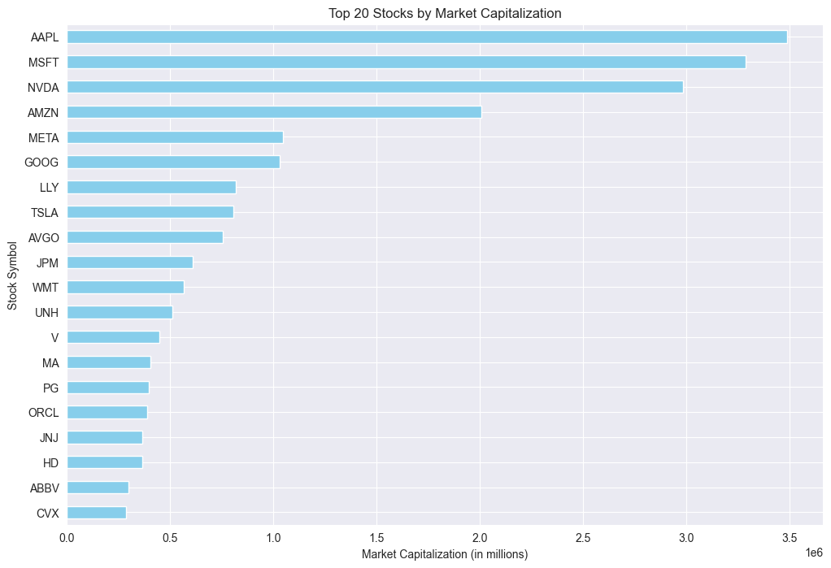

```python
# Top 20 stocks by market capitalization
top_20_stocks = df.groupby("symbol")["market_cap"].last().nlargest(20)

# Step 3: Plot the top 20 stocks
plt.figure(figsize=(12, 8))
top_20_stocks.sort_values().plot(kind='barh', color='skyblue')
plt.title("Top 20 Stocks by Market Capitalization")
plt.xlabel("Market Capitalization (in millions)")
plt.ylabel("Stock Symbol")
plt.show()
```

#### Daily Volatility as a Percentage of Stock Price

The daily volatility $(\sigma_{\text{daily}})$ is calculated as:

$$ \sigma_{\text{daily}} = {\sqrt{\frac{1}{N-1} \sum_{i=1}^{N} \left( r_i - \overline{r} \right)^2}} $$

Where:

N is the number of trading days. r_i represents the daily return on day i. $\overline{r}$ is the average daily return over the N days.

#### Annualized Volatility

Once the daily volatility is calculated, it is annualized using the following equation:

$$ \sigma_{\text{annual}} = \sigma_{\text{daily}} \times \sqrt{252} $$

Where:

$\sigma_{\text{daily}}$ is the standard deviation of the stock’s daily returns. The factor $\sqrt{252}$ annualizes the volatility, assuming there are 252 trading days in a year.

```python
df_daily = df.groupby('symbol').resample('D').agg({
    'close': 'last'
}).dropna() # dropna to remove Saturdays and Sundays
# Calculate the daily log returns
df_daily['return'] = df_daily.groupby('symbol')['close'].transform(lambda x: np.log(x / x.shift(1)))
# Calculate the rolling standard deviation of the daily returns
window_size = 30
df_daily['rolling_std'] = df_daily.groupby('symbol')['return'].rolling(window=window_size, min_periods=1).std().reset_index(0, drop=True)
# Annualize the volatility
df_daily['hist_vol'] = (df_daily['rolling_std'] * np.sqrt(252))
df_daily['hist_vol'] = df_daily['hist_vol'].fillna(method='bfill')
# Merge the daily historical volatility back into the original DataFrame
df_daily["symbol"] = df_daily.index.get_level_values(0)
df_daily["datetime"] = df_daily.index.get_level_values(1)
df_daily = df_daily.reset_index(drop=True)
df_daily["date"] = df_daily["datetime"].dt.date
minute_index = df.index
df = df.merge(df_daily[['symbol', 'date', 'hist_vol']], on=['symbol', 'date'], how='left').set_index(minute_index)
```

#### Shares Float

The float of a stock is the number of shares available for trading of a particular stock. It is calculated by taking the total number of shares outstanding and subtracting the shares held by insiders, employees, and major shareholders. The float is an important metric for traders because it indicates the number of shares available for trading in the open market. Speculative traders love low float stocks because they can be easily manipulated by institutions with relatively small amount of money. The risk increases when trading these stocks because you might not be able to sell your position at the price you want (due to low liquidity and wild price swings).

```python
df["shares_float"] = df["symbol"].apply(lambda x: fundamental_data[x]["float_shares"])
```

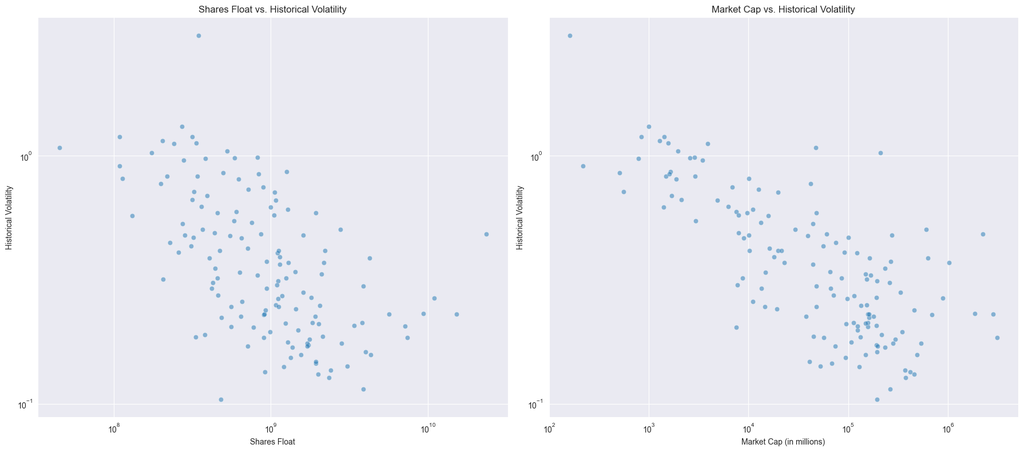

```python
hist_and_float_df = df.groupby('symbol').agg({
    'hist_vol': 'mean',
    'shares_float': 'last',
    'market_cap': 'mean'
}).dropna()

# Create a 1x2 grid of plots
fig, axes = plt.subplots(1, 2, figsize=(18, 8))

# Plot 1: Shares Float vs. Historical Volatility
sns.scatterplot(data=hist_and_float_df, x='shares_float', y='hist_vol', alpha=0.5, ax=axes[0])
axes[0].set_xscale('log')
axes[0].set_yscale('log')
axes[0].set_title('Shares Float vs. Historical Volatility')
axes[0].set_xlabel('Shares Float')
axes[0].set_ylabel('Historical Volatility')

# Plot 2: Market Cap vs. Shares Float
sns.scatterplot(data=hist_and_float_df, x='market_cap', y='hist_vol', alpha=0.5, ax=axes[1])
axes[1].set_xscale('log')
axes[1].set_yscale('log')
axes[1].set_title('Market Cap vs. Historical Volatility')
axes[1].set_xlabel('Market Cap (in millions)')
axes[1].set_ylabel('Historical Volatility')

# Show the plots
plt.tight_layout()
plt.show()
```

**We can see how a stock's shares float and market cap correlate with its volatility. It is clear from the scatter plot that the more volatile stocks tend to have lower float and lower market cap. This is because the less volatile stocks are usually the big cap stocks that are heavily traded by big institutions and retail traders. The low float stocks are usually the small cap stocks that are not heavily traded by institutions and are more susceptible to manipulation.**

### ATR

The Average True Range (ATR) is a technical analysis indicator that measures market volatility by calculating the average of the true range over a specified period. This indicator is used to identify stocks that usually make aggressive moves intraday. The ATR is calculated using the following steps:

1. True Range (TR): The True Range is the greatest of the following three values: $$ TR_t = \max\left( H_t - L_t, \, |H_t - C_{t-1}|, \, |L_t - C_{t-1}| \right) $$ where: $H_t$ = High price of the current period $L_t$ = Low price of the current period $C_{t-1}$ = Closing price of the previous period
2. Average True Range (ATR): The ATR is then calculated as the exponential moving average (EMA) of the True Range over a specified period n: $$ ATR_t = \frac{1}{n} \sum_{i=0}^{n-1} TR_{t-i} $$ or more commonly using the recursive formula: $$ ATR_t = \frac{(ATR_{t-1} \times (n-1)) + TR_t}{n} $$ where: $ATR_t$ = Average True Range at time t $TR_t$ = True Range at time t n = Number of periods (e.g., 14 periods is common)

We will calculate the daily ATR for each stock in the dataset, with a period of 14 days.

```python
df_daily = get_daily_df(df,{
    'close': 'last',
    'high': 'max',
    'low': 'min'
})
minute_index = df.index
df_daily["TR"] = ta.true_range(high=df_daily['high'], low=df_daily['low'], close=df_daily['close'])
df_daily["ATR"] = ta.atr(high=df_daily['high'], low=df_daily['low'], close=df_daily['close'], length=14)
df = df.merge(df_daily[['symbol', 'date', 'ATR', 'TR']], on=['symbol', 'date'], how='left')
df.set_index(minute_index, inplace=True)
df["ATR"] = df["ATR"].fillna(method='bfill')
df["TR"] = df["TR"].fillna(method='bfill')
df["ATR"] = df["ATR"] / df["close"] # Normalize ATR by the stock price
df["TR"] = df["TR"] / df["close"] # Normalize TR by the stock price
```

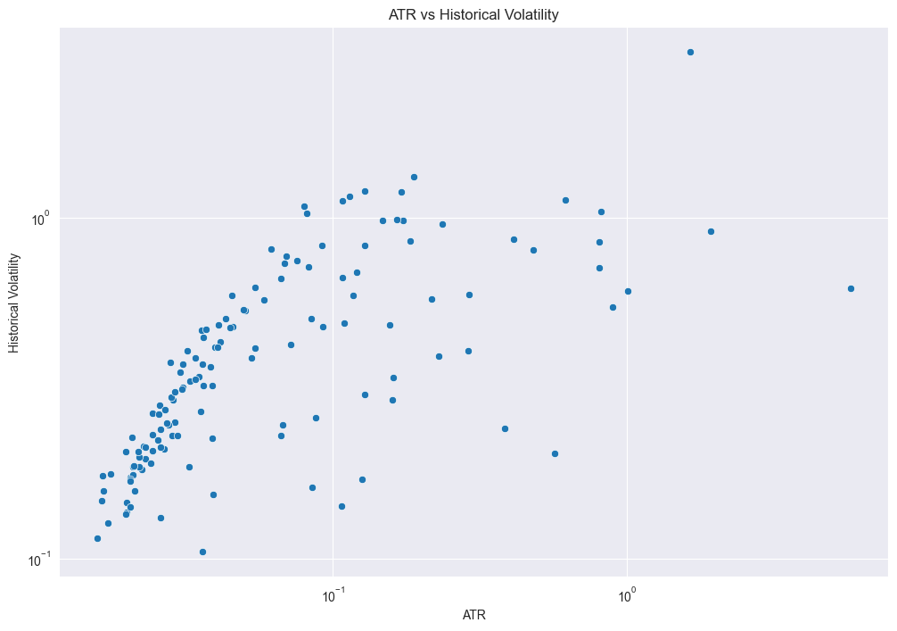

```python
# plot correlation between ATR and hist_vol
data = df.groupby("symbol").agg({"hist_vol": "mean", "ATR": "mean"}).dropna()
plt.figure(figsize=(12, 8))
sns.scatterplot(data=data, x="ATR", y="hist_vol")
plt.title("ATR vs Historical Volatility")
plt.xscale("log")
plt.yscale("log")
plt.xlabel("ATR")
plt.ylabel("Historical Volatility")
plt.show()
```

**We can see a high correlation between ATR and historical volatility. This is expected because ATR is a measure of volatility intraday and historical volatility is a measure of dispersion of returns. The more volatile a stock is, the more likely it is to make aggressive moves intraday.**

### Earnings Dates

Earnings dates are important for traders because they can cause big moves in the stock price. Companies usually release their earnings reports before the market opens or after the market closes. If the earnings are better than expected, the stock price usually goes up, and if they are worse than expected, the stock price usually goes down. Days that follow earnings releases are usually very volatile and can provide good trading opportunities.

```python
from utils import get_next_trading_day

fundamental_data_df = pd.DataFrame.from_dict(fundamental_data, orient='index').explode("earning_dates").dropna()
def get_date_following_earning(date_str):
    datetime_ = datetime.strptime(date_str, "%Y-%m-%d %H:%M:%S")
    if datetime_.hour < 16:
        return datetime_.date()
    else:
        return get_next_trading_day(datetime_).date()

fundamental_data_df["date_after_earnings"] = fundamental_data_df["earning_dates"].apply(get_date_following_earning)
fundamental_data_df["date"] = fundamental_data_df["earning_dates"].apply(lambda x: datetime.strptime(x, "%Y-%m-%d %H:%M:%S").date())
```

```python
df_index = df.index
df = df.merge(fundamental_data_df.reset_index()[["index", "date", "date_after_earnings"]], left_on=["symbol", "date"], right_on=["index", "date"], how="left").drop(columns=["index"]).rename(columns={"date_after_earnings": "is_earnings_day"}).fillna(False).set_index(df_index)
df["is_earnings_day"] = df["is_earnings_day"].apply(lambda date: True if date else False)
```

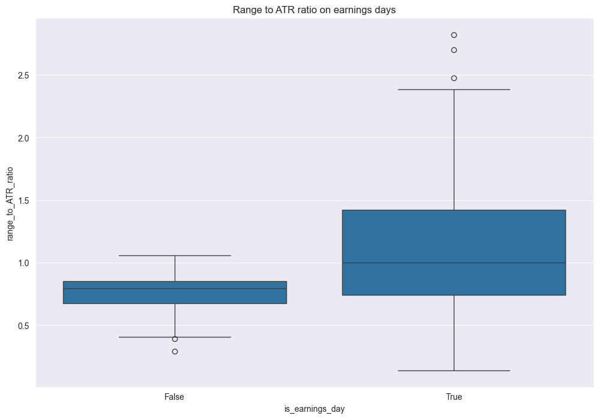

```python
# range is defined as the intra-day price range of a stock
range = df.groupby(["symbol", "date"])["high"].transform("max") - df.groupby(["symbol", "date"])["low"].transform("min")
df["range_to_ATR_ratio"] = range / df["close"] / df["ATR"]
plot_agg = df.groupby(["symbol", "is_earnings_day"])["range_to_ATR_ratio"].mean().reset_index()
# plot boxplot of TR to ATR ratio on earnings days
plt.figure(figsize=(12, 8))
sns.boxplot(data=plot_agg, x="is_earnings_day", y="range_to_ATR_ratio")
plt.title("Range to ATR ratio on earnings days")
plt.show()
```

**We can see that post-earnings days tend to be more volatile than regular trading days. This is expected because earnings releases can cause big moves in the stock price. The boxplot shows that the range to ATR ratio is higher on earnings days than on regular trading days. A stock's range does not take into account the gap between the previous day's close and the current day's open**

### Volume And Relative Volume

Volume is the number of shares traded during a given period of time. Days with larger volume play a significant role in determining key prices and trends. High volume days can indicate the presence of institutional traders, which can be a good signal for retail traders to follow. High volume days can also indicate the presence of news or other catalysts that can move the stock price. Average daily volume is calculated as the average of the volume over the past 30 days. Rel volume at time t on day i is calculated as the sum of the volume from day start to t, divided by the average volume of the stock on day i. Stocks that have a big rel volume early in the day with a large price move, attract speculative traders. $$ \text{Rel Volume}_t = \frac{\sum_{i=0}^{t} \text{Volume}_i}{\text{Average Volume}} $$

```python
df_daily = get_daily_df(df,{
    'volume': 'sum'
})
df_daily = df_daily[df_daily["volume"] > 0]
df_daily["average_volume"] = df_daily.groupby("symbol")["volume"].rolling(window=30, min_periods=1).mean().reset_index(0, drop=True)
df_index = df.index
df = df.merge(df_daily[["symbol", "date", "average_volume"]], on=["symbol", "date"], how="left").set_index(df_index)
df["rel_volume"] = df.groupby(["symbol", "date"])["volume"].cumsum() / df["average_volume"]
```

As day traders, we want to focus on stocks that have a high rel volume and pretty early during the day. This gives us the most volatility and liquidity

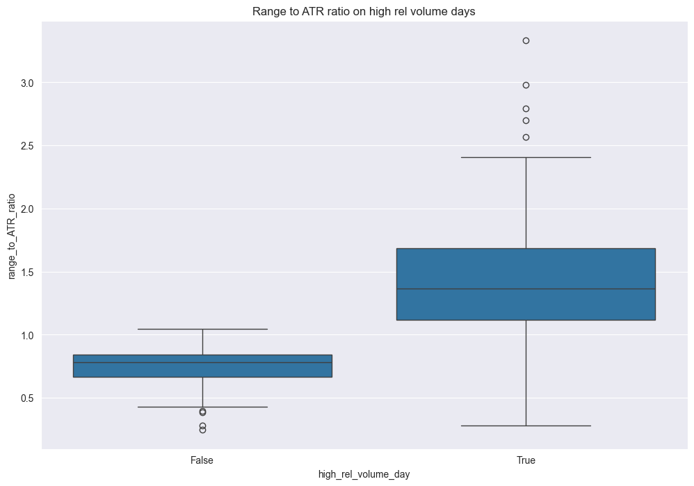

```python
high_rel_vol_at_10 = 0.5 # 50% of average daily volume traded in the first half hour
df["is_high_rel_early_candle"] = (df["rel_volume"] > high_rel_vol_at_10) & (df["hour"] == 9)
df["high_rel_volume_day"] = df.groupby(["symbol", "date"])["is_high_rel_early_candle"].transform("max")
# plot boxplot of TR to ATR ratio on high rel volume days compared to regular days
plot_agg = df.groupby(["symbol", "high_rel_volume_day"])["range_to_ATR_ratio"].mean().reset_index()
plt.figure(figsize=(12, 8))
sns.boxplot(data=plot_agg, x="high_rel_volume_day", y="range_to_ATR_ratio")
plt.title("Range to ATR ratio on high rel volume days")
plt.show()
```

Some traders think that Rel Volume can also be a good gauge of move confirmations. That means, if a stock is moving up on high volume early in the day, it is more likely to continue moving up. If a stock is moving down on high volume, it is more likely to continue moving down. These trades are usually the smoothest and have the best risk-reward, because the direction is very clear, all that is needed is to "ride the trend".

```python
df["change_from_open"] = df.groupby(["symbol", "date"]).apply(lambda x: x["close"] - x["open"].iloc[0]).reset_index(drop=True).values
df["change_from_open"] = df["change_from_open"] / df["open"] # Transform to percentage
```

### correlation between rel volume and price action

To see if rel volume can "confirm" move directions, we can look at the average change from open of the stock between 10:00 and 12:00 and compare it to the change from open at exactly 10:00. Then we can see the correlation between the change from open and the rel volume at 10:00.

```python
change_from_open_at_10 = df[(df["hour"] == 10) & (df["minute"] == 0)].groupby(["symbol", "date"])["change_from_open"].first().reset_index()
change_from_open_10_12 = df[(df["hour"] < 12) & (df["hour"] >= 10)].groupby(["symbol", "date"])["change_from_open"].mean().reset_index()
rel_volume_at_10 = df[(df["hour"] == 10) & (df["minute"] == 0)][["symbol", "rel_volume", "date", "ATR"]]
```

```
Average rel volume at 10:00: 0.5210903954664297
```

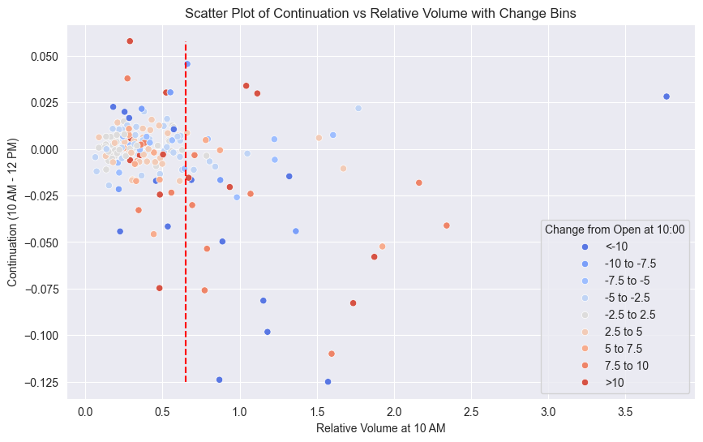

```python
joined = change_from_open_at_10.merge(change_from_open_10_12, on=["symbol", "date"], suffixes=("_10", "_10_12_mean"))
joined = joined.merge(rel_volume_at_10, on=["symbol", "date"]).rename(columns={"rel_volume": "rel_volume_10"})
# we want to focus on days where the move is large in the first half hour of the day, like days where the change from open is greater than the ATR
joined = joined[joined["change_from_open_10"].abs() > joined["ATR"]]
change_bins = [-np.inf, -0.10, -0.075, -0.05, -0.025, 0.025, 0.05, 0.075, 0.10, np.inf]
change_labels = ['<-10', '-10 to -7.5', '-7.5 to -5', '-5 to -2.5', '-2.5 to 2.5', '2.5 to 5', '5 to 7.5', '7.5 to 10', '>10']
# Bin the change_from_open_10 values
joined['change_bin'] = pd.cut(joined['change_from_open_10'], bins=change_bins, labels=change_labels, include_lowest=True)
joined["is_positive_change"] = joined["change_from_open_10"] > 0
joined["continuation_move"] = joined["change_from_open_10_12_mean"] - joined["change_from_open_10"]
print(f"Average rel volume at 10:00: {joined['rel_volume_10'].mean()}")

# Scatter plot for negative days
plt.figure(figsize=(10, 6))
sns.scatterplot(x='rel_volume_10', y='continuation_move', hue='change_bin', data=joined, palette='coolwarm', legend='full')
plt.title("Scatter Plot of Continuation vs Relative Volume with Change Bins")
plt.xlabel("Relative Volume at 10 AM")
plt.ylabel("Continuation (10 AM - 12 PM)")
plt.legend(title='Change from Open at 10:00')
plt.vlines(0.65, min(joined['continuation_move']), max(joined['continuation_move']), colors='r', linestyles='dashed')
plt.show()
```

**The scatter plot shows us that on days where the stock has move **up** in the first half-hour on very large rel volume, it is more likely to reverse in the following 2 hours. But when the stock has a large move **down** in the first half-hour on very large rel volume, it is more likely to continue moving down in the following 2 hours, this maybe explained by the fact that the stock traders are panicking and selling their positions. On the other hand, rel volume tells us nothing when it is low or average, or when the stock has not moved much in the first half-hour.**

Let's see how it plays out in shorter intervals, we will take the change and rel volume at 9:45 and compare it to the period between 9:45 and 10:15 the same way we did above

```python
change_from_open_at_945 = df[(df["hour"] == 9) & (df["minute"] == 45)].groupby(["symbol", "date"])["change_from_open"].first().reset_index()
change_from_open_945_10_15 = df[(df["hour"] < 10) & (df["hour"] >= 9) & (df["minute"] >= 45)].groupby(["symbol", "date"])["change_from_open"].mean().reset_index()
rel_volume_at_945 = df[(df["hour"] == 9) & (df["minute"] == 45)][["symbol", "rel_volume", "date", "ATR"]]
```

```
Average rel volume at 9:45: 0.2974440604472087
```

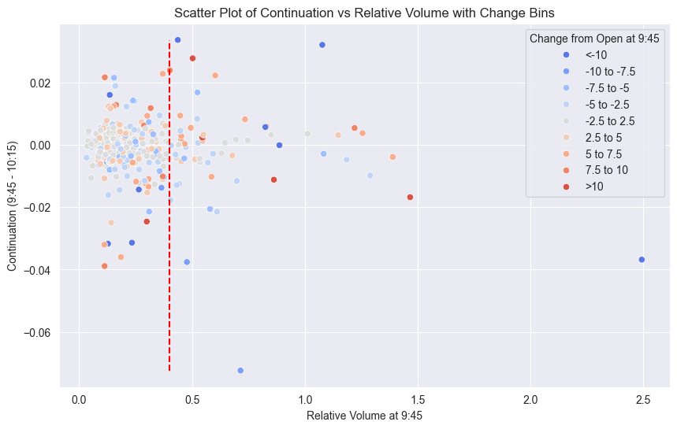

```python
joined = change_from_open_at_945.merge(change_from_open_945_10_15, on=["symbol", "date"], suffixes=("_945", "_945_10_15_mean"))
joined = joined.merge(rel_volume_at_945, on=["symbol", "date"]).rename(columns={"rel_volume": "rel_volume_945"})
# we want to focus on days where the move is large in the first 15 minutes of the day, like days where the change from open is greater than 0.5ATR
joined = joined[joined["change_from_open_945"].abs() > joined["ATR"] * 0.75]
# Bin the change_from_open_10 values
joined['change_bin'] = pd.cut(joined['change_from_open_945'], bins=change_bins, labels=change_labels, include_lowest=True)
joined["is_positive_change"] = joined["change_from_open_945"] > 0
joined["continuation_move"] = joined["change_from_open_945_10_15_mean"] - joined["change_from_open_945"]
print(f"Average rel volume at 9:45: {joined['rel_volume_945'].mean()}")
# Scatter plot for negative days
plt.figure(figsize=(10, 6))
sns.scatterplot(x='rel_volume_945', y='continuation_move', hue='change_bin', data=joined, palette='coolwarm', legend='full')
plt.title("Scatter Plot of Continuation vs Relative Volume with Change Bins")
plt.xlabel("Relative Volume at 9:45")
plt.ylabel("Continuation (9:45 - 10:15)")
plt.legend(title='Change from Open at 9:45')
plt.vlines(0.4, min(joined['continuation_move']), max(joined['continuation_move']), colors='r', linestyles='dashed')
plt.show()
```

### Gaps

Gaps are a common occurrence in the stock market. A gap is a break between prices on a chart that occurs when the price of a stock makes a sharp move up or down with no trading occurring in between. Gaps can be caused by a number of factors, such as news, earnings reports, or market sentiment. Traders often look for gaps as they can provide good trading opportunities. There are four types of gaps:

1. Common gaps: These gaps are usually small and are often filled quickly.
2. Breakaway gaps: These gaps occur when the price breaks out of a trading range.
3. Runaway gaps: These gaps occur during a strong trend and indicate that the trend is likely to continue.
4. Exhaustion gaps: These gaps occur at the end of a trend and signal that the trend is likely to reverse.

Gaps analysis takes into account daily gaps which are the difference between the previous day's close and the current day's open. Gaps are very common after earnings, as the investor's reaction to the earnings report moves the stock in the pre-market or after-market. Let's analyze the correlation between gap fills on the daily chart and the volume of the stock in the day of the gap.

```python
daily_df = df.groupby(["symbol", "date"]).agg({
    "close": "last",
    "open": "first",
    "high": "max",
    "low": "min",
    "volume": "sum",
    "average_volume": "first"
}).reset_index()
daily_df["previous_close"] = daily_df.groupby("symbol")["close"].shift(1).fillna(daily_df["close"])
daily_df["gap"] = daily_df["open"] - daily_df["previous_close"]
gaps = daily_df[daily_df["gap"].abs() > daily_df["close"] * 0.01] # Filter out small gaps
gaps["is_positive"] = gaps["gap"] > 0
gaps["has_gap_filled_intraday"] = gaps.apply(lambda row: row["low"] <= row["previous_close"] if row["is_positive"] else row["high"] >= row["previous_close"], axis=1)
gaps["gap_size"] = gaps["gap"] / gaps["close"]
gaps["volume_to_average_volume"] = gaps["volume"] / gaps["average_volume"]
gaps["close_percentile_of_range"] = (gaps["close"] - gaps["low"]) / (gaps["high"] - gaps["low"])
df_index = df.index
df = df.merge(daily_df[["symbol", "date", "gap"]], on=["symbol", "date"], how="left").set_index(df_index)
```

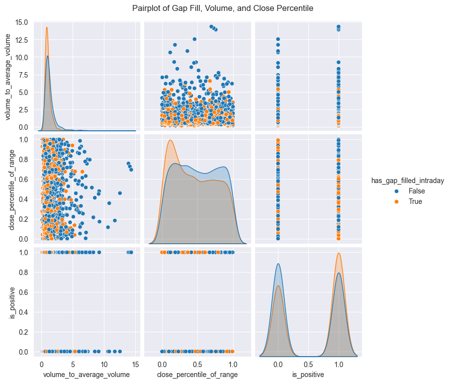

```python
# Selecting the relevant columns for correlation
correlation_data = gaps[["has_gap_filled_intraday", "volume_to_average_volume", "close_percentile_of_range", "is_positive"]]
sns.pairplot(correlation_data, hue="has_gap_filled_intraday")
plt.suptitle("Pairplot of Gap Fill, Volume, and Close Percentile", y=1.02)
plt.show()
```

**The relationship between close_percentile_of_range and volume_to_average_volume. is very interesting. It shows us that if the gap is not filled intraday, the stock is likely to close in the upper bound of the range, especially on high volume days. This means that the stock can either continue in one direction after the gap and close around the highs (or lows for down days), or it can retest the gap and that bounce back in the original direction. The bottom right graph is also informative. It shows that negative gaps are less likely to fill than positive gaps, which makes shorting negative gaps is likelier to succeed than going long on positive gaps.**

### Technical Analysis Indicators

1. Moving Averages

Moving averages are widely used in technical analysis to smooth out price data and identify trends. We will compute simple moving averages (SMA) for long trends and exponential moving averages (EMA) for intraday bars to understand the general direction of the market over different time frames.

```
•	Simple Moving Average (SMA): A basic average of closing prices over a specific period.
•	Exponential Moving Average (EMA): A weighted average that gives more importance to recent prices.
```

We’ll visualize how these moving averages interact with the price data and observe potential crossovers that may signal trend reversals or continuations.

2. Support and Resistance Levels

Support and resistance levels are critical price points where the market tends to reverse or consolidate. These levels are identified by analyzing historical price data and are used by traders to determine entry and exit points. Support and resistance lines can be calculated both on daily basis and on minute basis for intraday analysis. They are calculated using fractals, which are local minima and maxima of the price chart.

```
•	Support Levels: Price levels where the asset tends to find buying interest and “support,” preventing the price from falling further.
•	Resistance Levels: Price levels where selling pressure tends to prevent the price from rising further.
```

We will plot these levels on the price chart to visualize how they impact price movements.

3. Relative Strength Index (RSI)

The Relative Strength Index (RSI) is a momentum oscillator that measures the speed and change of price movements. It ranges from 0 to 100 and is used to identify overbought or oversold conditions in the market.

```
•	RSI > 70: Typically indicates that the asset is overbought and may be due for a correction.
•	RSI < 30: Typically indicates that the asset is oversold and may be due for a bounce.
```

#### Moving Averages

```python
ema_one_minute_bars = 9 * 5 # a common value for EMA lookback period is 45 minutes
sma_daily_bars = 50 # a common value for SMA lookback period on daily bars is 50 days
# Calculate the EMA and SMA
df['EMA'] = df.groupby(['symbol', 'date'])['close'].transform(lambda x: x.ewm(span=ema_one_minute_bars).mean())
df_daily = get_daily_df(df, {"close": "first"}) # we take the first close of each day to not "leak" future data into the minute bars
df_daily['SMA'] = df_daily.groupby('symbol')['close'].transform(lambda x: x.rolling(window=sma_daily_bars, min_periods=1).mean()) # very important to take the rolling moving average on the daily bars to avoid data leakage from future prices into current ones
index = df.index
df = df.merge(df_daily[['symbol', 'date', 'SMA']], on=['symbol', 'date'], how='left').set_index(index).rename({'SMA': 'daily_sma'})
```

```python
# Let's plot APPLE's daily bars with 50 day sma, and the first day of trading with 45 minute ema.
df_daily = get_daily_df(df, {"open": "first", "high": "max", "low": "min", "close": "last", "SMA": "mean"})
df_daily.set_index(pd.to_datetime(df_daily["date"]), inplace=True)
aapl_daily = df_daily[df_daily["symbol"] == "AAPL"][["open", "high", "low", "close", "SMA"]]
aapl_daily_sma = aapl_daily["SMA"]
aapl_minute = df[df["symbol"] == "AAPL"]
aapl_minute = aapl_minute[aapl_minute["date"] == df["date"].iloc[0]] # Plot the first day
aapl_minute_ema = aapl_minute["EMA"]
```

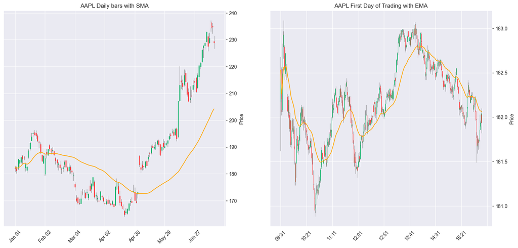

```python
fig, (ax_daily, ax_minute) = plt.subplots(1, 2, figsize=(18, 8))
daily_addplot = mpf.make_addplot(aapl_daily_sma, panel=0, color='orange', ax=ax_daily)
minute_addplot = mpf.make_addplot(aapl_minute_ema, panel=0, color='orange', ax=ax_minute)
plot_bars_with_indicators(aapl_daily, ax_daily, title="AAPL Daily bars with SMA", addplots=[daily_addplot])
plot_bars_with_indicators(aapl_minute, ax_minute, title="AAPL First Day of Trading with EMA", addplots=[minute_addplot])
plt.show()
```

**In intraday trading, the EMA is a good indicator of the stock's short term trend, and can act as support for when the stock is in an upward trend, and as resistance when the stock is in a downward trend. The SMA on the daily level is a good indicator of the stock's long term trend, and acts similarly to EMA but on a daily basis. The SMA can also be a pivot point in intraday trading, for example, if a stock that is in an uptrend opens below the SMA, the SMA can act as a resistance level when touched intraday. Similarly, if a stock that is in a downtrend opens above the SMA, the SMA can act as a support level when touched intraday. A popular but basic trading strategy is "mean reversion" (implemented later) assumes that prices always "mean revert", which means that price tends to return to its average price over time. Traders that use this strategy on the intraday level might short the stock when it has been above the EMA for an extended period, and similarly go long when it has been below the EMA for an extended period.**

#### Support and Resistance Levels

```python
# resistances column holds the resistance levels (from the past) for each day
df_daily["resistances"] = df_daily.progress_apply(
    lambda x: historic_resistances(
        df_daily,
        x["symbol"],
        x["date"],
        peak_rank_w_pct=0.03, # group peaks that are within 3% of the stock price
        strong_peak_prominence_pct=0.05, # strong peaks have a prominence of at least 5%
        strong_peak_distance=10, # strong peaks are at least 10 bars away from each other
        peak_distance=5, # peaks are at least 5 bars away from each other
    ), axis=1
)
df_daily["supports"] = df_daily.progress_apply(
    lambda x: historic_supports(
        df_daily,
        x["symbol"],
        x["date"],
        trough_rank_w_pct=0.03,
        strong_trough_prominence_pct=0.05,
        strong_trough_distance=10,
        trough_distance=5,
    ), axis=1)
df_daily["resistances"] = df_daily.apply(lambda row: row["resistances"] if row["resistances"][0] > 0 else [], axis=1)
df_daily["supports"] = df_daily.apply(lambda row: row["supports"] if row["supports"][0] > 0 else [], axis=1)
```

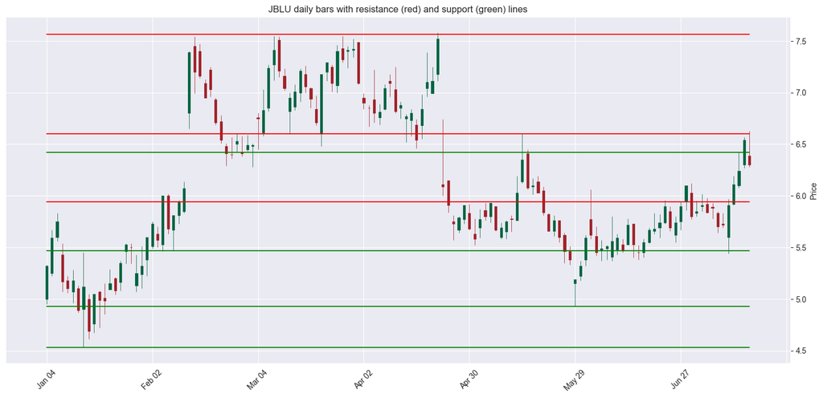

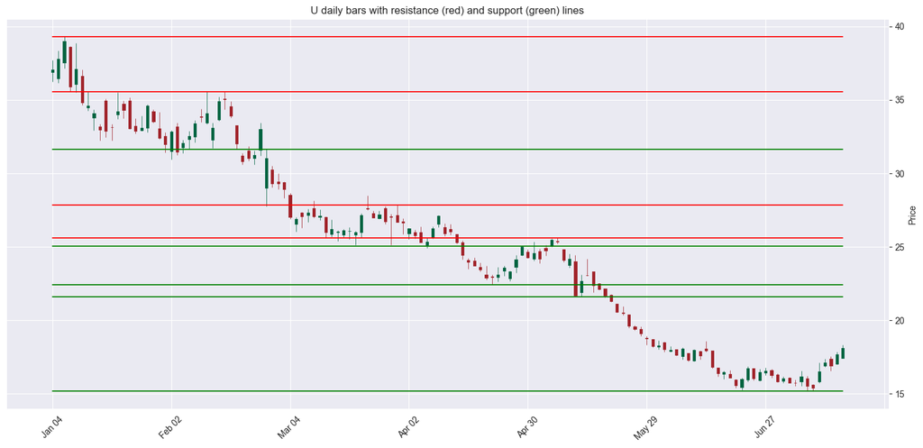

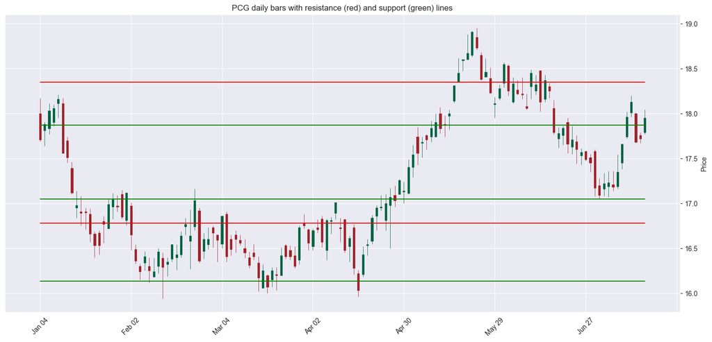

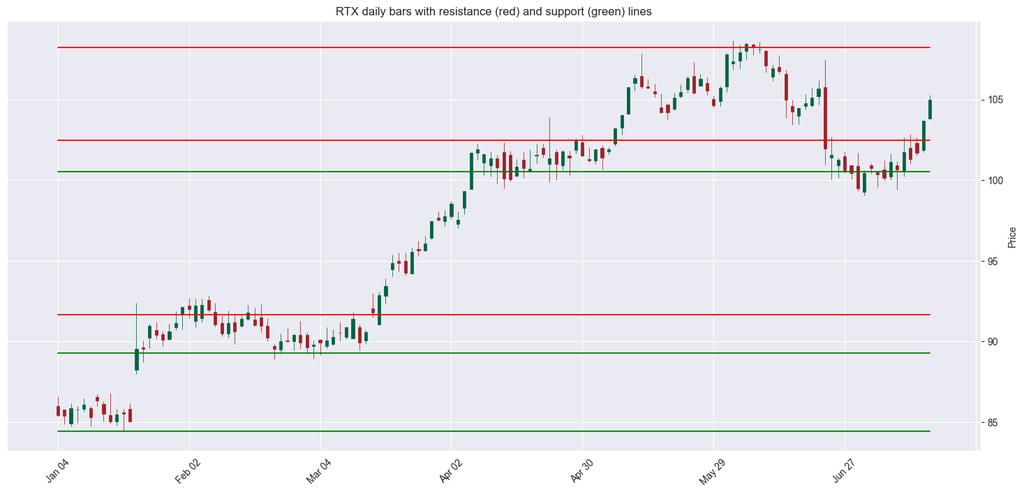

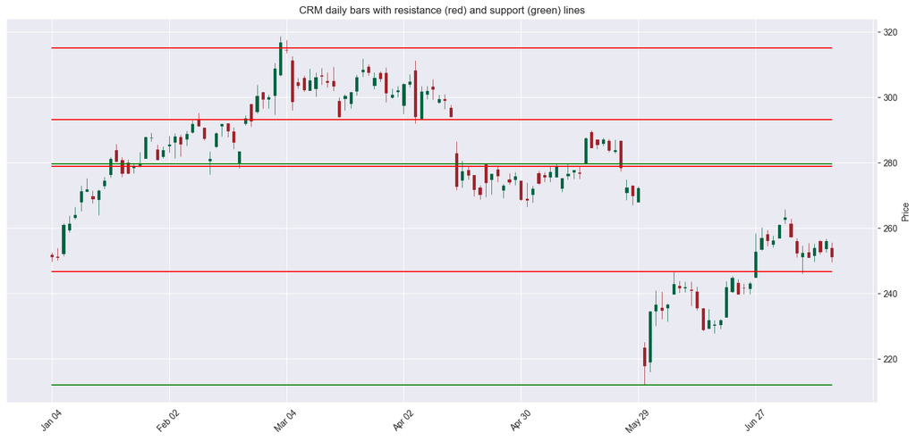

```python
from plots import plot_with_resistances_and_supports

# plotting support and resistance for stocks
symbols = df_daily.sample(5)["symbol"].values
for symbol in symbols:
    daily = df_daily[df_daily["symbol"] == symbol]
    fig, ax = plt.subplots(figsize=(18, 8))
    ax.set_title(f"{symbol} daily bars with resistance (red) and support (green) lines")
    plot_with_resistances_and_supports(daily,  ax)
```

> Note: The support and resistance lines shown are from the last row of each daily dataframe. If we only look at rows up to index i, these lines will be different. This is because the algorithm calculates the support and resistance levels based on past data, so the levels can change as new data comes in.

**"Key Levels"** Once a stock closes above a resistance or below a support line, the support price may turn into a resistance price and vice versa. Instead of treating these levels as "resistance" and "support" levels, traders call them "key levels". Key levels are important because they are more likely to act as pivot points.

```python
df_daily["key_levels"] = df_daily.apply(lambda x: x["resistances"] + x["supports"], axis=1)
df_daily.reset_index(inplace=True, drop=True)
index = df.index
df = df.merge(df_daily[['symbol', 'date', 'key_levels']], on=['symbol', 'date'], how='left').set_index(index)
df.set_index(index, inplace=True)
```

```python
# Let's see how intraday price interacts with key levels
def key_levels_in_daily_range(row):
    touched_levels = [level for level in row["key_levels"] if level >= row["low"] and level <= row["high"]]
    return touched_levels[0] if touched_levels else None

def key_levels_in_gap(row):
    if row["gap"] > 0:
        touched_levels = [level for level in row["key_levels"] if level >= row["previous_close"] and level <= row["open"]]
    else:
        touched_levels = [level for level in row["key_levels"] if level <= row["previous_close"] and level >= row["open"]]
    return touched_levels[0] if touched_levels else None

def did_pivot(row):
    # If the stock closed and opened on the same side of the key level
    return (
        row["close"] > row["key_level_in_daily_range"] and row["open"] > row["key_level_in_daily_range"]
        ) or (
        row["close"] < row["key_level_in_daily_range"] and row["open"] < row["key_level_in_daily_range"]
    )

df_daily = get_daily_df(df, {"volume": "sum", "low": "min", "high": "max", 'close': 'last', 'open': 'first', "key_levels": "first"})
df_daily["key_level_in_daily_range"] = df_daily.apply(key_levels_in_daily_range, axis=1)
df_daily["did_pivot"] = df_daily.apply(did_pivot, axis=1)
df_daily["previous_close"] = df_daily.groupby("symbol")["close"].shift(1).fillna(daily_df["close"])
df_daily["gap"] = df_daily["open"] - df_daily["previous_close"]
df_daily["key_level_in_gap"] = df_daily.apply(key_levels_in_gap, axis=1)
df = df.merge(df_daily[["symbol", "date", "key_level_in_daily_range", "did_pivot"]], on=["symbol", "date"], how="left").set_index(index)
```

```python
key_levels_touched_intraday_df = df[~df["key_level_in_daily_range"].isna()]
```

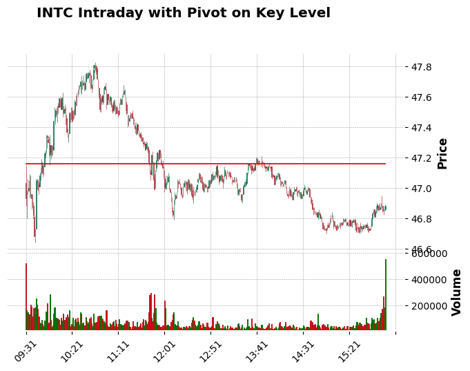

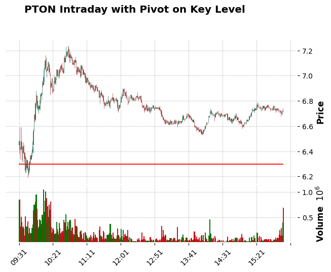

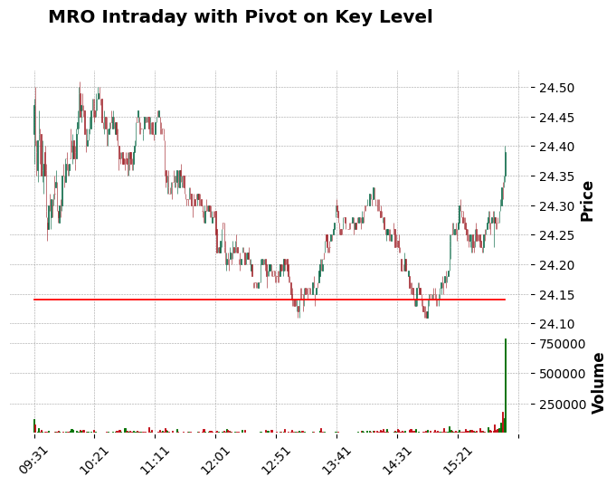

```python
from plots import plot_intraday_with_key_level

# plot a few charts where the price pivoted on key level and where it didn't
pivoted = key_levels_touched_intraday_df[key_levels_touched_intraday_df["did_pivot"]]
symbols = pivoted.sample(3).symbol.unique()
for symbol in symbols:
    symbol_df = pivoted[pivoted["symbol"] == symbol]
    symbol_df = symbol_df[symbol_df["date"] == symbol_df["date"].iloc[0]] # Plot the first day
    plot_intraday_with_key_level(symbol_df, is_pivot=True)
```

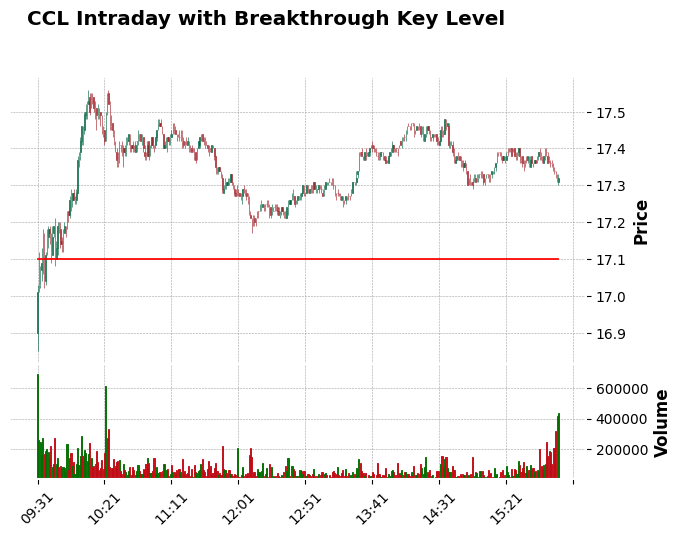

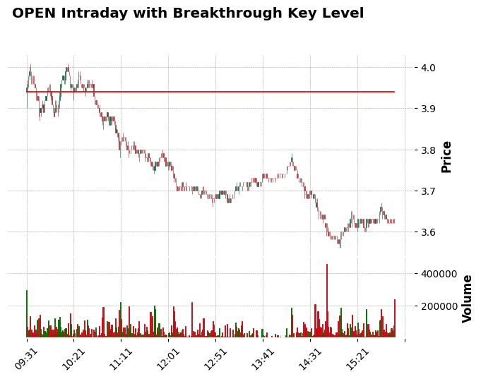

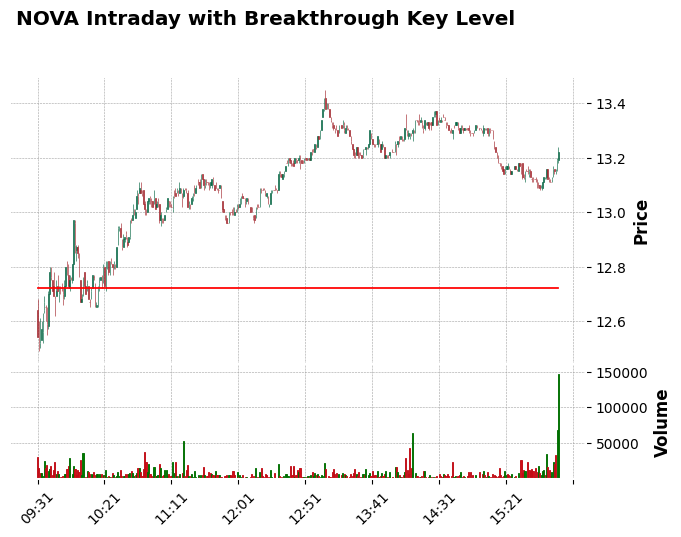

```python
not_pivoted = key_levels_touched_intraday_df[~key_levels_touched_intraday_df["did_pivot"]]
symbols = not_pivoted.sample(3).symbol.unique()
for symbol in symbols:
    symbol_df = not_pivoted[not_pivoted["symbol"] == symbol]
    symbol_df = symbol_df[symbol_df["date"] == symbol_df["date"].iloc[0]] # Plot the first day
    plot_intraday_with_key_level(symbol_df)
```

#### Relative Strength Index (RSI)

RSI is calculated using the following formula:

1. Calculate the Price Changes (ΔP):

   • For each period, compute the difference between the current price and the previous price: $$ \Delta P = P_{\text{current}} - P_{\text{previous}} $$ • If the result is positive, it is an upward change; if negative, it is a downward change.
2. Calculate the Average Gain and Average Loss:

   • Over a specified period (commonly 14 days), calculate the average of all upward changes (gains) and the average of all downward changes (losses). $$ \text{Average Gain} = \frac{\sum(\text{Gains over the period})}{\text{Number of periods}}

\text{Average Loss} = \frac{\sum(\text{Losses over the period})}{\text{Number of periods}} $$ 3. Calculate the Relative Strength (RS): • The Relative Strength is the ratio of the Average Gain to the Average Loss: $$ RS = \frac{\text{Average Gain}}{\text{Average Loss}} $$ 4. Calculate the RSI: • The RSI is calculated using the RS value and the following formula: $$ RSI = 100 - \frac{100}{1 + RS} $$

We’ll calculate the RSI and plot it below the price chart to analyze potential overbought or oversold conditions.

```python
df['RSI'] = df.groupby('symbol')['close'].transform(lambda x: ta.rsi(x, window=10)).fillna(50) # fillna 50 to represent neutral RSI
```

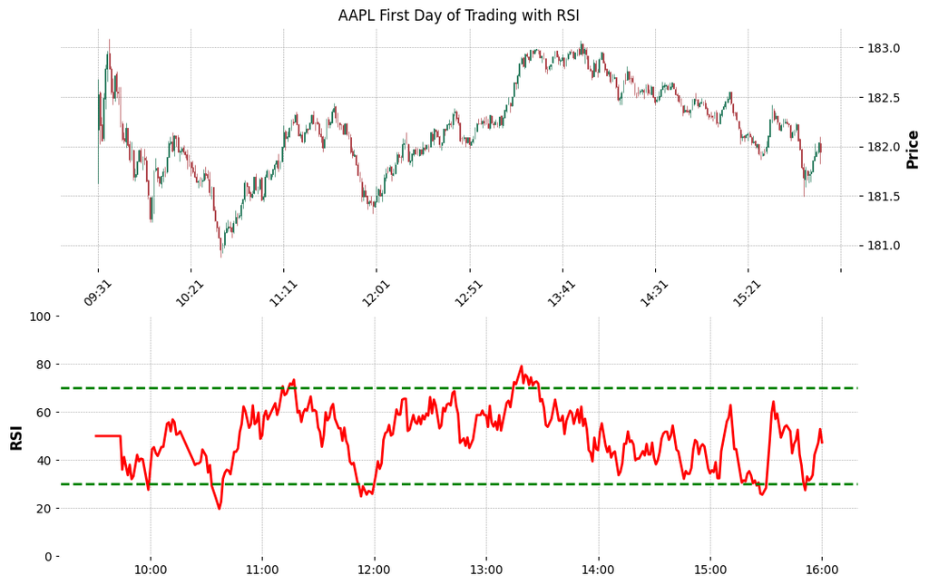

```python
from plots import plot_with_rsi

fig, (ax1, ax2) = plt.subplots(2, 1, figsize=(12, 8))
ax1.set_title("AAPL First Day of Trading with RSI")

plot_with_rsi(df[(df["symbol"] == "AAPL") & (df["date"] == df["date"].iloc[0])], ax1, ax2)
```

**As demonstrated in the example here, the stock becomes "overbought" when RSI is above 70, and we can see that indeed on this trading day, AAPL stock had a peak when RSI crossed above 70. The same for bottoms, when RSI crossed below 30, the stock became "oversold" and went back to rising. While telling us a lot about the trend of the stock, RSI going above or below our threshold doesn't necessarily mean the stock is going to reverse. If a stock is being bought aggressively we can see the RSI staying above 70 for long periods of time, but it is a good indicator of trend.**

# Section 2: Backtesting

Backtesting is the process of testing a trading strategy or model on historical data to assess its performance. By simulating trades using historical data, backtesting allows traders and analysts to evaluate how a strategy would have performed in the past. This is a critical step in developing any trading strategy, as it provides insights into the strategy’s potential profitability, risk, and overall behavior under different market conditions.

Key Components of Backtesting:

1. Historical Data: Accurate and comprehensive historical data is essential for backtesting. This data typically includes prices (open, high, low, close), volume, and other relevant market data, such as technical indicators or fundamental factors.
2. Trading Strategy: The strategy defines the rules for entering and exiting trades. These rules can be based on technical indicators (e.g., moving averages, RSI), fundamental analysis, or a combination of both. The strategy also includes parameters such as position sizing and risk management rules.
3. Execution: In backtesting, the strategy is applied to the historical data, generating a sequence of trades based on the defined rules. This process simulates how the strategy would have performed if it had been applied in the past.
4. Performance Metrics: After running the backtest, various performance metrics are calculated to assess the strategy’s effectiveness. Common metrics include: • **Cumulative Profit and Loss (PnL)**: The total gain or loss from the strategy over the backtesting period. • **Maximum Drawdown**: The largest peak-to-trough decline during the backtest, indicating the potential risk of the strategy. • **Sharpe Ratio**: A measure of risk-adjusted return, showing how much excess return the strategy generated per unit of risk. Sharpe ratio = (average return - risk-free rate) / standard deviation of returns. • **Winning Percentage**: The percentage of trades that were profitable. • **Trade Count**: The total number of trades executed during the backtest.

**Because the amount of compute in this project is limited to my M1 Macbook, I will only backtest the strategies on the 10 stocks with the highest average volume in the dataset. The ML model will be trained on 10 stocks in the period between 01-01-2024 till 01-06-2024 and tested on the period between 01-06-2024 till the end of my dataset**

I will use the metrics described in 4 to evaluate our baseline strategies, and then our ML model - based strategy. Since the ML based strategy will be trained on a train period and tested on a test period, we will also limit the back tests of our baseline strategies to the same periods.

## Baseline Trading Strategies

In this section, we will implement three simple trading strategies that we will compare with our ML-based trading strategy later. These strategies are:

1. **Buy and Hold**: This strategy involves buying the stock on the first day and holding it forever (until our cutoff date). This strategy is often used as a baseline because it is the easiest to execute and does not require any work other than buying the stock.
2. **Mean Reversion Strategy**: This strategy assumes that prices always revert to their mean value. It involves buying a stock when the price is 1 standard deviation below the EMA and selling when the price is 1 standard deviation above the EMA. The position is closed if the stock crosses EMA or the day is over.
3. **RSI strategy**: This strategy involves buying a stock when the RSI is below 30 (indicating oversold conditions) and selling when the RSI is above 70 (indicating overbought conditions). The position is closed when RSI reaches 50 or when the day is over.

Each trade will be 1000$ in size and we ignore commissions, our entries are calculated based on closing prices.

```python
TRAIN_PERIOD_END = "2024-06-01"
VAL_PERIOD_END = "2024-06-10"
LIMIT_STOCKS = 10
```

```python
top_10_average_volume_stocks = df.groupby("symbol")["average_volume"].mean().nlargest(LIMIT_STOCKS).index
df = df[df["symbol"].isin(top_10_average_volume_stocks)]
print(f"Top 10 stocks by average volume: {top_10_average_volume_stocks}")
```

```
Top 10 stocks by average volume: Index(['NVDA', 'FFIE', 'TSLA', 'AMD', 'NIO', 'PLTR', 'F', 'SOFI', 'AAPL',
       'PLUG'],
      dtype='object', name='symbol')
```

```python
if RUN_BACKTESTS:
    bnh_strategy_metrics = {}
    ema_strategy_metrics = {}
    rsi_strategy_metrics = {}
    df["date"] = pd.to_datetime(df["date"])
    for symbol in df["symbol"].unique():
        stock_df = df[df["symbol"] == symbol]
        bnh_strategy_metrics[symbol] = backtest_bnh_strategy(stock_df, VAL_PERIOD_END)
        ema_strategy_metrics[symbol] = backtest_ema_strategy(stock_df, VAL_PERIOD_END)
        rsi_strategy_metrics[symbol] = backtest_rsi_strategy(stock_df, VAL_PERIOD_END)
    print("Buy and Hold Strategy Metrics")
    describe_strategy_result(bnh_strategy_metrics)
    print("Mean Reversion Strategy Metrics")
    describe_strategy_result(ema_strategy_metrics)
    print("RSI Strategy Metrics")
    describe_strategy_result(rsi_strategy_metrics)
```

```
Buy and Hold Strategy Metrics
Total unique stocks traded: 10
Total money used: 10000
Total PnL across all stocks: 792.04
Total PnL % of money used: 7.92%
Average PnL per stock: 79.20
Max drawdown: 0.00
Average Sharpe ratio: 0.00
Average winning trades ratio: 40.00%
Total trades: 10
Best stock PnL: 361.90 - TSLA
Worst stock PnL: -276.93 - FFIE
PnL Per Stock: TSLA    361.9000
PLTR    235.2100
F       192.7000
AAPL    160.0500
SOFI    135.3600
PLUG     69.8000
AMD     -18.3600
NVDA    -20.0800
NIO     -47.6100
FFIE   -276.9285
Name: total_pnl, dtype: float64
Mean Reversion Strategy Metrics
Total unique stocks traded: 10
Total money used: 10000
Total PnL across all stocks: -299.57
Total PnL % of money used: -3.00%
Average PnL per stock: -29.96
Max drawdown: 206.14
Average Sharpe ratio: -0.01
Average winning trades ratio: 47.09%
Total trades: 6789
Best stock PnL: 635.43 - SOFI
Worst stock PnL: -485.33 - NVDA
PnL Per Stock: SOFI    635.430
AMD     244.150
PLTR    165.820
NIO     -35.640
F       -66.000
```

[output cut: 14 more lines]

```
Average winning trades ratio: 47.02%
Total trades: 1090
Best stock PnL: 96.99 - AMD
Worst stock PnL: -263.75 - FFIE
PnL Per Stock: AMD      96.9900
NVDA     71.1700
F        60.1500
PLUG     59.5100
AAPL     42.7100
SOFI     24.2000
PLTR     12.2200
TSLA    -33.5500
NIO     -96.9200
FFIE   -263.7484
Name: total_pnl, dtype: float64
```

# Section 3: Machine Learning Model

**Temporal Fusion Transformer (TFT)** is a state-of-the-art deep learning model for time series forecasting. It is based on the Transformer architecture and is designed to capture complex temporal patterns in sequential data. The TFT model consists of an encoder-decoder architecture with multiple attention layers that allow it to learn from historical data and make accurate predictions about future trends. TFT is designed to incorporate both time-dependant data and static data, predict multiple-horizons and be highly explainable, which makes it suitable for our use case. It uses quantile regression to predict multiple quantiles of the target distribution, which allows us to estimate the uncertainty of our predictions.

[figure not shown]

## Pre processing and feature selection

We use most of the features calculated in the above sections, and add key levels on hourly bases. In TFT, the data is split to 3 categories:

1. **time varying known variables** - those are variables that are fed both into the encoder and the decoder LSTM blocks, and are known in advance. In our dataset they are:
- "day_of_the_week"
- "is_earnings_day"
- "hour"
- "minute"
- "average_volume"
- "time_idx"
2. **time varying unknown variables** - these variables are not known in advance in future steps and are only fed to the encoder LSTM blocks. In our case they are
- "open"
- "high"
- "low"
- "close"
- "rel_volume"
- "ATR"
- "EMA"
- "RSI"
- "SMA"
- "market_cap"
- "gap"
- "daily_key_level_above_current_price"
- "daily_key_level_below_current_price"
- "hourly_key_level_above_current_price"
- "hourly_key_level_below_current_price"
3. static variables - these variables don't change over time and are static. These variable values change across time series (different stocks in our case). We take "industry" and "shares_float" as the static variables.

```python
from utils import get_hourly_df

#multi time frame analysis - find support and resistance on different time frames. We will use the key levels from daily hourly and 5 minute time frames.
hourly_df = get_hourly_df(df, {"close": "last", "high": "max", "low": "min"})
hourly_df["resistances"] = hourly_df.progress_apply(
    lambda x: historic_resistances(
        df_daily,
        x["symbol"],
        x["date"],
        peak_rank_w_pct=0.005, # group peaks that are within 0.5% of the stock price
        strong_peak_prominence_pct=0.02, # strong peaks have a prominence of at least 2%
        strong_peak_distance=96, # strong peaks are at least 96 hours away from each other
        peak_distance=4, # peaks are at least 4 hours away from each other
        include_high=False
    ), axis=1
)
hourly_df["supports"] = hourly_df.progress_apply(
    lambda x: historic_supports(
        df_daily,
        x["symbol"],
        x["date"],
        trough_rank_w_pct=0.005,
        strong_trough_prominence_pct=0.02,
        strong_trough_distance=96,
        trough_distance=4,
        include_low=False
    ), axis=1
)
hourly_df["key_levels"] = hourly_df.apply(lambda x: x["resistances"] + x["supports"], axis=1)
hourly_df["date"] = pd.to_datetime(hourly_df["date"])
df["date"] = pd.to_datetime(df["date"])
hourly_df["hour"] = hourly_df["date"].dt.hour
df_index = df.index
df = df.merge(hourly_df[["symbol", "date", "hour" , "key_levels"]], on=["symbol", "date", "hour"], how="left", suffixes=("","_hourly")).set_index(df_index)
```

```python
df["industry"] = df["symbol"].apply(lambda x: fundamental_data[x]["industry"]).astype("category")
```

```python
df["key_levels_hourly"] = df["key_levels_hourly"].fillna(0)
df["key_levels_hourly"] = df["key_levels_hourly"].apply(lambda x: x if x != 0 else [])
```

```python
df["month"] = df["date"].dt.month
df["day"] = df["date"].dt.day
def create_time_idx(group):
    # Use pd.factorize to create a continuous index for each symbol's time series
    group['time_idx'] = pd.factorize(group.index)[0]
    return group
df_index = df.index
df = df.groupby('symbol').apply(create_time_idx).reset_index(drop=True).set_index(df_index)
df["month"] = df["month"].astype(str).astype("category")
df["day_of_the_week"] = df["date"].dt.dayofweek.astype(str).astype("category")
df["is_earnings_day"] = df["is_earnings_day"].apply(lambda x: "yes" if x else "no").astype("category")
```

```python
df["gap"] = df["gap"] / df["close"] # Transform to percentage
def find_closest_resistance(row, col_name="key_levels"):
    resistances = [level for level in row[col_name] if level > row["close"]]
    if not resistances:
        return row["high"]
    return min(resistances)
def find_closest_support(row, col_name="key_levels"):
    supports = [level for level in row[col_name] if level < row["close"]]
    if not supports:
        return row["low"]
    return max(supports)

df["daily_key_level_above_current_price"] = df.apply(
    find_closest_resistance,
    axis=1
)
df["hourly_key_level_above_current_price"] = df.apply(
    find_closest_resistance,
    axis=1,
    col_name="key_levels_hourly"
)
df["daily_key_level_below_current_price"] = df.apply(
    find_closest_support,
    axis=1
)
df["hourly_key_level_below_current_price"] = df.apply(
    find_closest_support,
    axis=1,
    col_name="key_levels_hourly"
)
```

```python
df["hour"] = df["hour"].astype(str).astype("category")
df["minute"] = df["minute"].astype(str).astype("category")
```

```python
df.to_parquet("processed.parquet")
```

```python
df = pd.read_parquet("processed.parquet")
```

```python
df_train = df[df["date"] < TRAIN_PERIOD_END]
df_val = df[(df["date"] >= TRAIN_PERIOD_END) & (df["date"] < VAL_PERIOD_END)]
df_test = df[df["date"] >= VAL_PERIOD_END]
```

```python
min_prediction_length = 10 # predict 10 minutes into the future
max_prediction_length = 10
min_encoder_length = 120 # 2 hours
max_encoder_length = 120
training_dataset = TimeSeriesDataSet(
    df_train.reset_index(),
    time_idx="time_idx",
    target="close",
    group_ids=["symbol"],
    min_encoder_length=min_encoder_length, # 4 hours
    max_encoder_length=max_encoder_length, # 4 hours
    min_prediction_length=min_prediction_length,
    max_prediction_length=max_prediction_length,
    time_varying_known_reals=[
         "time_idx", "average_volume"
    ],
    time_varying_known_categoricals=[
        "day_of_the_week", "is_earnings_day", "hour", "minute"
    ],
    time_varying_unknown_reals=[
        "open", "high", "low", "close", "rel_volume", "ATR", "EMA", "RSI", "SMA", "market_cap", "gap",
        "daily_key_level_above_current_price", "daily_key_level_below_current_price", "hourly_key_level_above_current_price", "hourly_key_level_below_current_price"
    ],
    static_categoricals=[
        "industry"
    ],
    static_reals=[
        "shares_float"
    ],
    lags={
        "close": [60, 120, 180], # previous close price
    },
    add_target_scales=True,
    add_relative_time_idx=True,
    add_encoder_length=False,
    target_normalizer=GroupNormalizer(
        groups=["symbol"], transformation="softplus"
    ),
    # scalers=scalers
)
batch_size = 128
train_dataloader = training_dataset.to_dataloader(train=True, batch_size=batch_size, num_workers=0)
validation = TimeSeriesDataSet.from_dataset(training_dataset, df_val.reset_index(), predict=True, stop_randomization=True)
val_dataloader = validation.to_dataloader(train=False, batch_size=batch_size * 10, num_workers=0)
```

```python
from lightning.pytorch.callbacks import ModelCheckpoint

lr_logger = LearningRateMonitor()  # log the learning rate
logger = TensorBoardLogger("lightning_logs")  # logging results to a tensorboard

checkpoint_callback = ModelCheckpoint(
    filename='intent_classifier-{epoch:02d}-{val_loss:.2f}',
    save_top_k=3,
    save_last=True,
    monitor="val_loss",
    mode="min",
    every_n_train_steps=200,
)

trainer = pl.Trainer(
    max_epochs=5,
    accelerator="mps",
    enable_model_summary=True,
    gradient_clip_val=0.1,
    # limit_train_batches=50,  # coment in for training, running valiation every 30 batches
    #fast_dev_run=True,  # comment in to check that networkor dataset has no serious bugs
    callbacks=[lr_logger, checkpoint_callback],
    val_check_interval=100,
    logger=logger,
)

tft = TemporalFusionTransformer.from_dataset(
    training_dataset,
    learning_rate=0.02,
    hidden_size=256,
    lstm_layers=1,
    attention_head_size=4,
    dropout=0.1,
    hidden_continuous_size=256,
    loss=QuantileLoss([0.3, 0.5, 0.7]), # 3 quantiles for uncertainty estimation
    log_interval=10,  # uncomment for learning rate finder and otherwise, e.g. to 10 for logging every 10 batches
    reduce_on_plateau_patience=100,
    optimizer="ranger"
)
print(f"Number of parameters in network: {tft.size()/1e3:.1f}k")
```

```
GPU available: True (mps), used: True
TPU available: False, using: 0 TPU cores
HPU available: False, using: 0 HPUs
```

```
Number of parameters in network: 11357.7k
```

```python
if IS_CLEAN_RUN:
    trainer.fit(
        tft,
        train_dataloaders=train_dataloader,
        val_dataloaders=val_dataloader,
    )
```

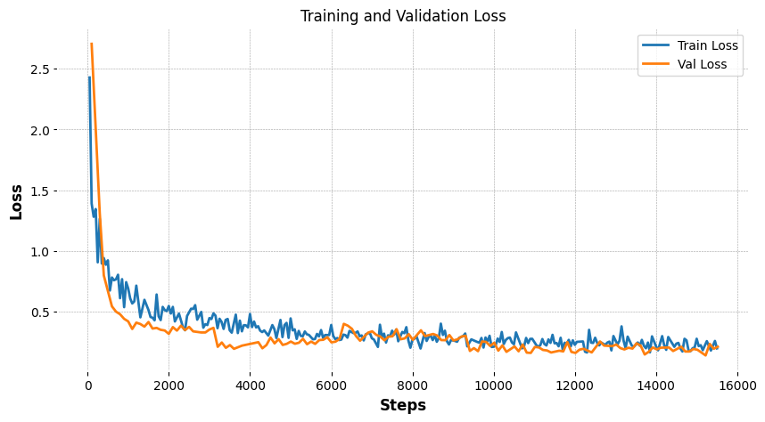

```python
if IS_CLEAN_RUN:
    model_path = checkpoint_callback.best_model_path
else:
    model_path = "lightning_logs/lightning_logs/version_2/checkpoints/intent_classifier-epoch=04-val_loss=0.15.ckpt"
best_tft = TemporalFusionTransformer.load_from_checkpoint(model_path)
event_acc = EventAccumulator("lightning_logs/lightning_logs/version_2")
event_acc.Reload()

# Retrieve scalar values for train_loss and val_loss
train_loss = event_acc.Scalars('train_loss_step')  # Match with your logged name
val_loss = event_acc.Scalars('val_loss')  # Match with your logged name

# Convert to NumPy arrays for easier plotting
train_steps = np.array([x.step for x in train_loss])
train_loss_values = np.array([x.value for x in train_loss])

val_steps = np.array([x.step for x in val_loss])
val_loss_values = np.array([x.value for x in val_loss])

# Plot train and validation loss
plt.figure(figsize=(10, 5))
plt.plot(train_steps, train_loss_values, label='Train Loss')
plt.plot(val_steps, val_loss_values, label='Val Loss')
plt.xlabel("Steps")
plt.ylabel("Loss")
plt.title("Training and Validation Loss")
plt.legend()
plt.show()
```

**The model seems to converge well, with the validation loss being lower than the training loss, which is a good sign.**

## Model Evaluation

Let's evaluate our model as a predictor of prices first before plugging it into a trading strategy. We will use the Mean Absolute Percentage Error (MAPE) as our metric. We will also plot variable importances and attention importances to understand what the model is looking at when making predictions.

```python
from pytorch_forecasting import MAPE

test_dataset = TimeSeriesDataSet.from_dataset(training_dataset, df_test.reset_index(), predict=True, stop_randomization=True)
test_dataloader = test_dataset.to_dataloader(train=False, batch_size=batch_size, num_workers=0)
predictions = best_tft.predict(test_dataloader, return_y=True, trainer_kwargs=dict(accelerator="cpu"))
print(f"test set MAPE: {MAPE()(predictions.output, predictions.y)}")
print(f"validation set MAPE: {MAPE()(best_tft.predict(val_dataloader, return_y=True).output, best_tft.predict(val_dataloader, return_y=True).y)}")
```

```
GPU available: True (mps), used: False
TPU available: False, using: 0 TPU cores
HPU available: False, using: 0 HPUs
GPU available: True (mps), used: True
TPU available: False, using: 0 TPU cores
HPU available: False, using: 0 HPUs
```

```
test set MAPE: 0.02172885835170746
```

```
GPU available: True (mps), used: True
TPU available: False, using: 0 TPU cores
HPU available: False, using: 0 HPUs
```

```
validation set MAPE: 0.0038204393349587917
```

#### Variable importances

The model has inbuilt interpretation capabilities due to how its architecture is build. Let’s see how that looks.

```
GPU available: True (mps), used: True
TPU available: False, using: 0 TPU cores
HPU available: False, using: 0 HPUs
```

```
{'attention': <Figure size 640x480 with 1 Axes>,
 'static_variables': <Figure size 700x300 with 1 Axes>,
 'encoder_variables': <Figure size 700x825 with 1 Axes>,
 'decoder_variables': <Figure size 700x450 with 1 Axes>}
```

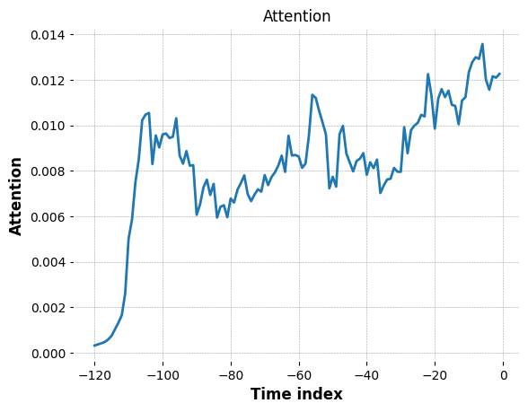

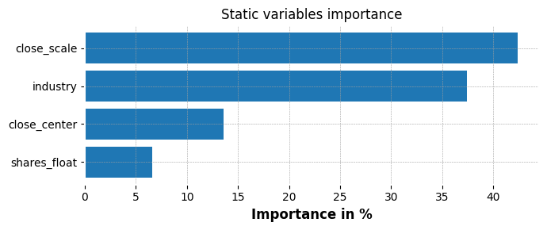

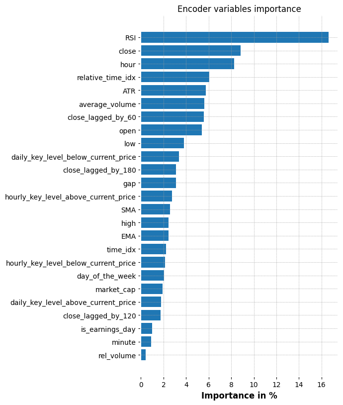

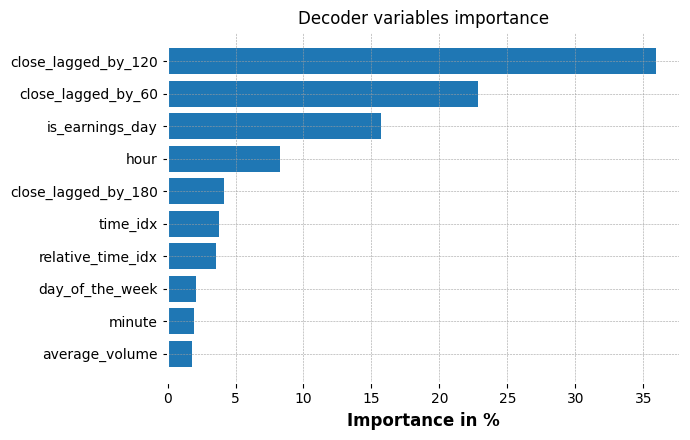

```python
raw_predictions = best_tft.predict(val_dataloader, mode="raw", return_x=True)
interpretation = best_tft.interpret_output(raw_predictions.output, reduction="sum")
best_tft.plot_interpretation(interpretation)
```

**Its good to see that all of our features are being used by the model. It is also interesting to mention that the key levels are not being used as much as the other features which I did not expect. The attention importance graph tells us that closer prices are more significant that prices that are further in the past**

```python
test_dataset = TimeSeriesDataSet.from_dataset(training_dataset, df_test.reset_index(), predict=False, stop_randomization=True)
test_dataloader = test_dataset.to_dataloader(train=False, batch_size=batch_size, num_workers=0)
```

```
GPU available: True (mps), used: True
TPU available: False, using: 0 TPU cores
HPU available: False, using: 0 HPUs
```

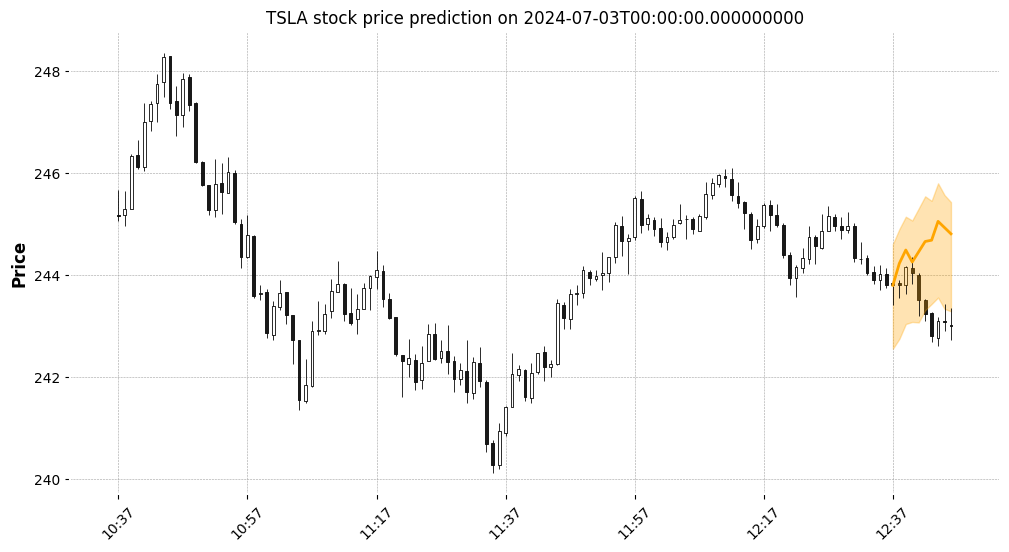

```
GPU available: True (mps), used: True
TPU available: False, using: 0 TPU cores
HPU available: False, using: 0 HPUs
```

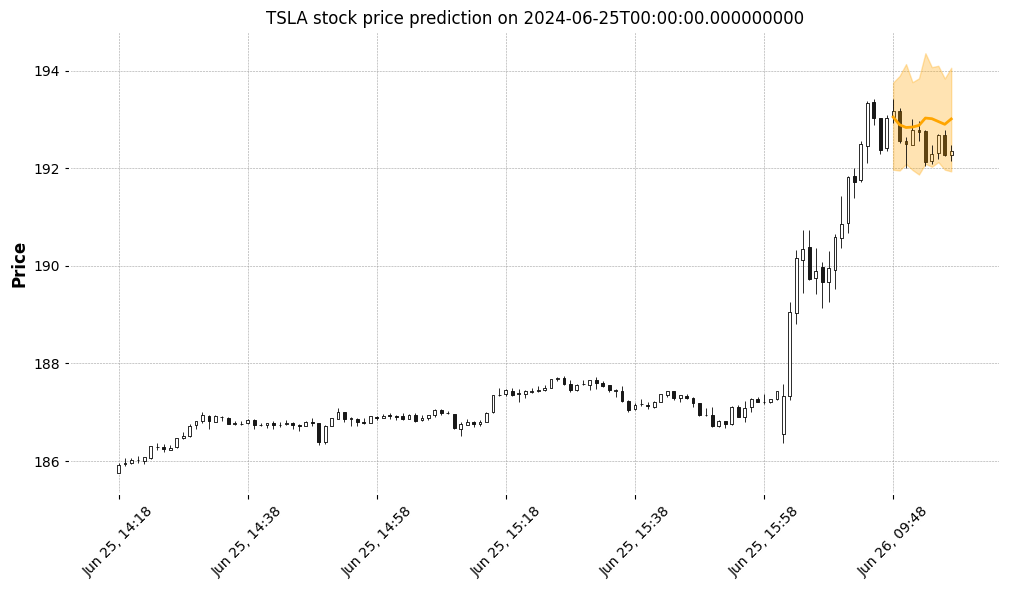

```
GPU available: True (mps), used: True
TPU available: False, using: 0 TPU cores
HPU available: False, using: 0 HPUs
```

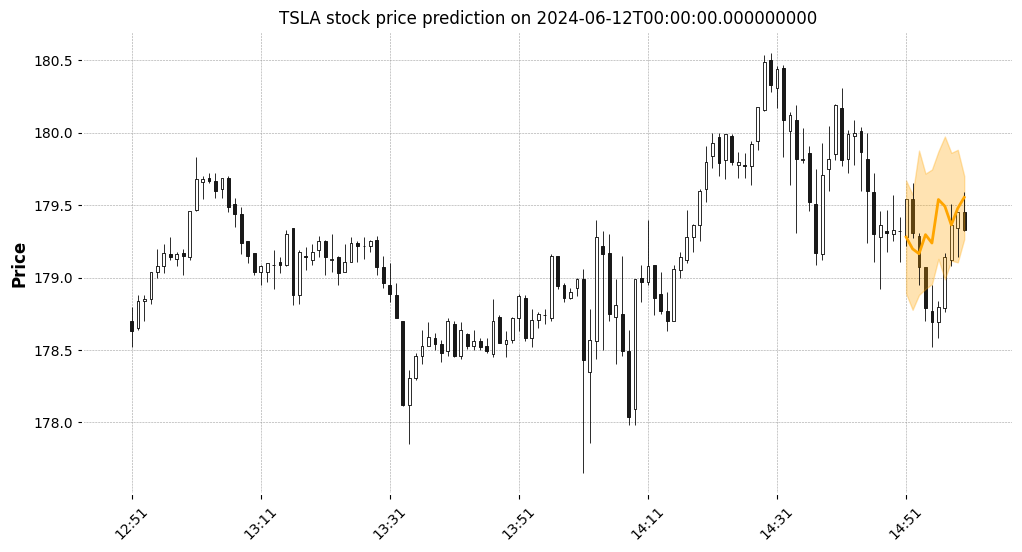

```
GPU available: True (mps), used: True
TPU available: False, using: 0 TPU cores
HPU available: False, using: 0 HPUs
```

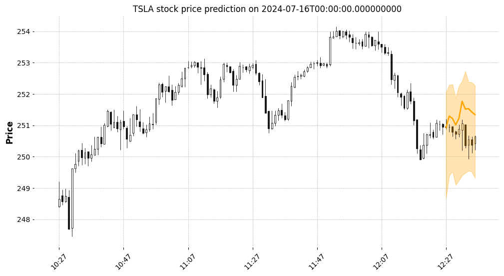

```
GPU available: True (mps), used: True
TPU available: False, using: 0 TPU cores
HPU available: False, using: 0 HPUs
```

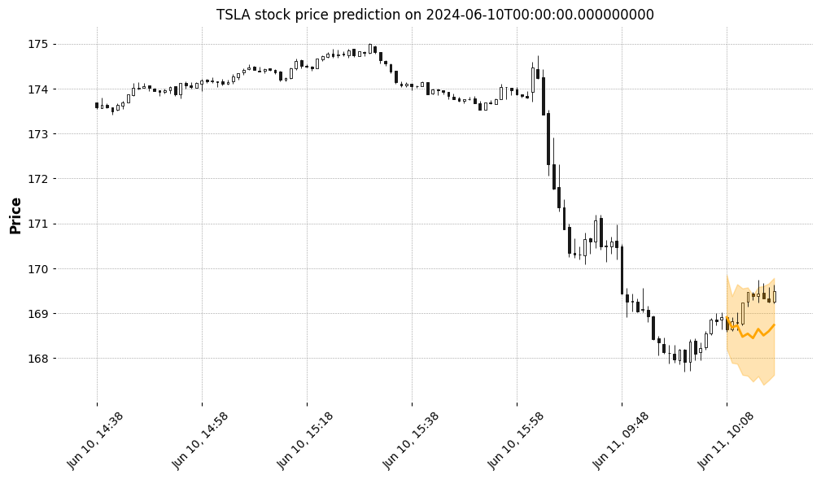

```python
for i in range(5):
    symbol = "TSLA"
    first_test_time_idx = test_dataset.filter(lambda x: x.symbol == symbol)[0][0]["encoder_time_idx_start"].item()
    first_test_time_idx += np.random.randint(0, df_test.time_idx.max() - first_test_time_idx)
    date = df_test[df_test["time_idx"] == first_test_time_idx]["date"].values[0]
    first_predict_point_time_idx = first_test_time_idx + min_encoder_length
    prediction = best_tft.predict(
        test_dataset.filter(lambda x: (x.symbol == symbol) & (x.time_idx_first_prediction == first_predict_point_time_idx)),
        mode="raw",
        return_x=True,
    )
    candles = df_test[(df_test["symbol"] == symbol) & (df_test["time_idx"] >= first_test_time_idx) & (df_test["time_idx"] < first_predict_point_time_idx+max_prediction_length)]
    fig, ax = plt.subplots(figsize=(12, 6))
    ax.set_title(f"{symbol} stock price prediction on {date}")
    prediction_quantile_30 = prediction.output.prediction[:, :, 0].cpu().numpy().squeeze(0)
    prediction_quantile_50 = prediction.output.prediction[:, :, 1].cpu().numpy().squeeze(0)
    prediction_quantile_70 = prediction.output.prediction[:, :, 2].cpu().numpy().squeeze(0)
    adjust_predictions = prediction_quantile_50[0] - candles.iloc[-max_prediction_length]["open"]
    prediction_quantile_50 -= adjust_predictions
    prediction_quantile_30 -= adjust_predictions
    prediction_quantile_70 -= adjust_predictions
    quantile_30 = np.concatenate([np.array([np.nan]*min_encoder_length), prediction_quantile_30])
    quantile_50 = np.concatenate([np.array([np.nan]*min_encoder_length), prediction_quantile_50])
    quantile_70 = np.concatenate([np.array([np.nan]*min_encoder_length), prediction_quantile_70])
    addplots = [
        mpf.make_addplot(quantile_50, type="line", color="orange", width=2, ax=ax),  # Middle line bold
    ]

    mpf.plot(
        candles,
        ax=ax,
        type="candle",
        addplot=addplots,
    )

    ax.fill_between(
        range(len(quantile_50)),  # x values
        quantile_30,  # bottom quantile (30)
        quantile_70,  # top quantile (70)
        color="orange", alpha=0.3  # fill color and transparency
    )
    plt.show()
```

```python
predictions = best_tft.predict(
    test_dataloader,
    mode="quantiles",
    return_index=True,
    trainer_kwargs=dict(accelerator="cpu")
)
```

```
GPU available: True (mps), used: False
TPU available: False, using: 0 TPU cores
HPU available: False, using: 0 HPUs
```

```python
predictions_df = pd.DataFrame({
    'symbol': predictions.index['symbol'],     # the symbol column from index_df
    'time_idx': predictions.index['time_idx'],   # the time index column from index_df
    'predictions': list(predictions.output.numpy())   # store each [10, 3] array as a list in the DataFrame
})
def adjust_predictions(row):
    if type(row["predictions"]) == float:
        return row
    adjust_scale = row["predictions"][0][1] - row["open"]
    row["predictions"] = row["predictions"] - adjust_scale

    return row
df_index = df_test.index
predictions_df = df_test.merge(predictions_df, on=['symbol', 'time_idx'], how='left').set_index(df_index)
predictions_df = predictions_df.apply(adjust_predictions, axis=1)
predictions_df = predictions_df[~predictions_df["predictions"].isna()]
predictions_df["change_prediction_q_50"] = predictions_df["predictions"].apply(lambda x: x[-1][1] - x[0][1])
predictions_df["change_prediction_q_30"] = predictions_df["predictions"].apply(lambda x: x[-1][0] - x[0][0])
predictions_df["change_prediction_q_70"] = predictions_df["predictions"].apply(lambda x: x[-1][2] - x[0][2])
predictions_df["change_actual"] = predictions_df["close"].shift(-10) - predictions_df["open"]
```

```python
predictions_df["direction_matches"] = predictions_df.apply(lambda x: np.sign(x["change_prediction_q_50"]) == np.sign(x["change_actual"]), axis=1)
direction_accuracy = predictions_df["direction_matches"].mean()
print(f"Directional accuracy: {direction_accuracy}")
```

```
Directional accuracy: 0.4546622461665976
```

**The model seems to be directionally accurate 45% of the time, which is worse than guessing. Still, let's see if we can build a trading strategy beats buy and hold**